# **Problem Statement**

### Distribution Plots

Distribution plot for case_status for predictor:continent

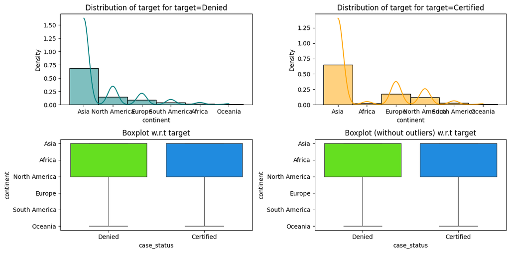

Distribution plot for case_status for predictor:education_of_employee

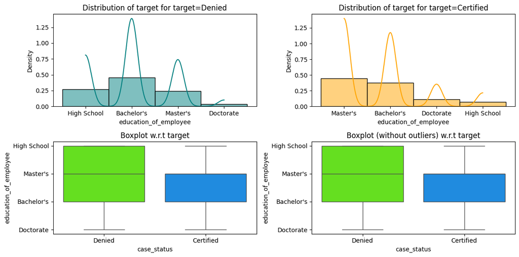

Distribution plot for case_status for predictor:has_job_experience

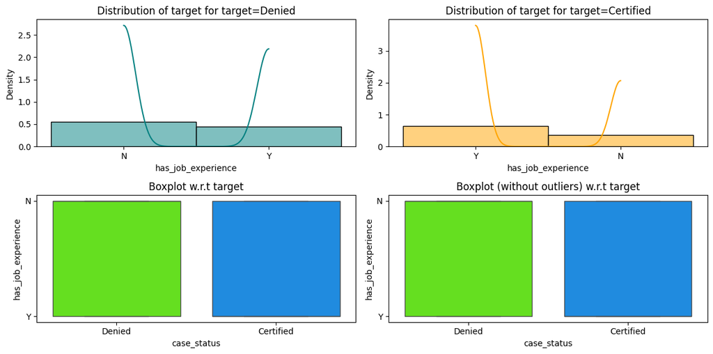

Distribution plot for case_status for predictor:requires_job_training

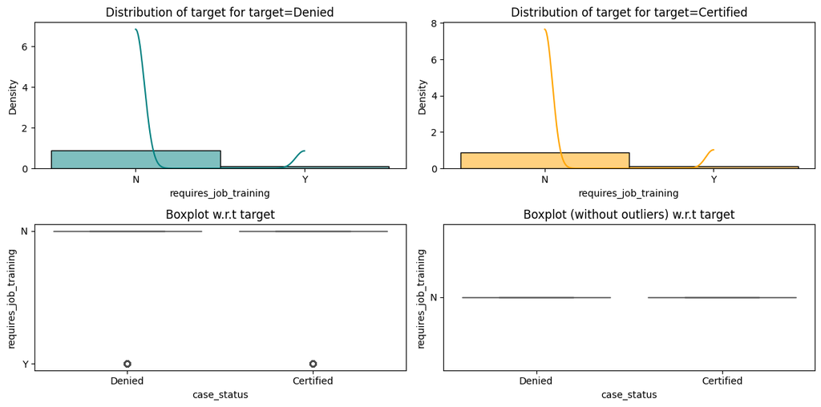

Distribution plot for case_status for predictor:no_of_employees

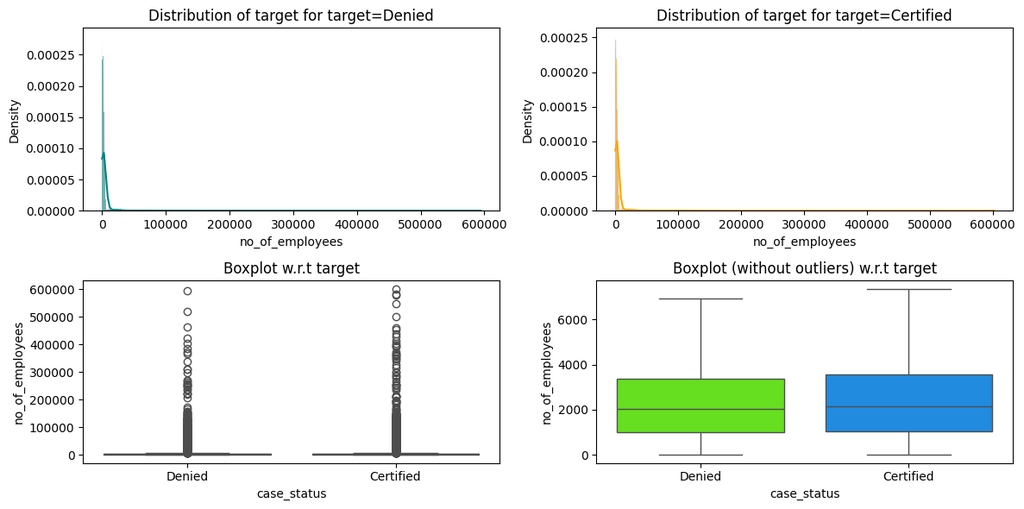

Distribution plot for case_status for predictor:yr_of_estab

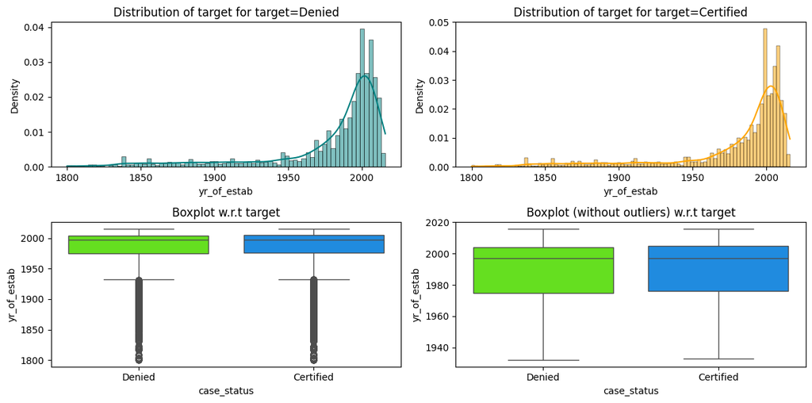

Distribution plot for case_status for predictor:region_of_employment

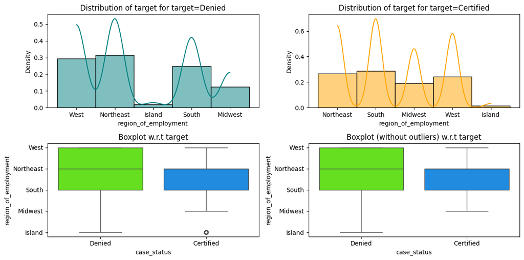

Distribution plot for case_status for predictor:prevailing_wage

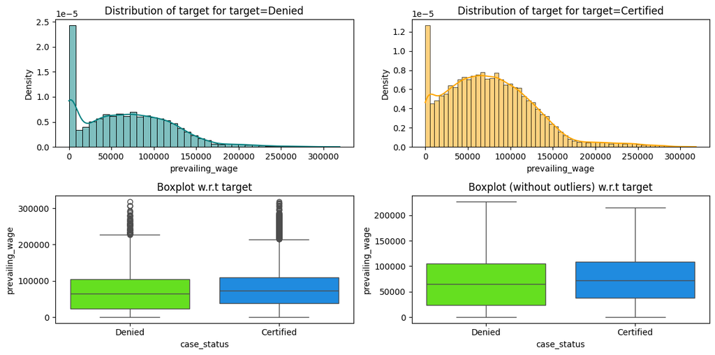

Distribution plot for case_status for predictor:unit_of_wage

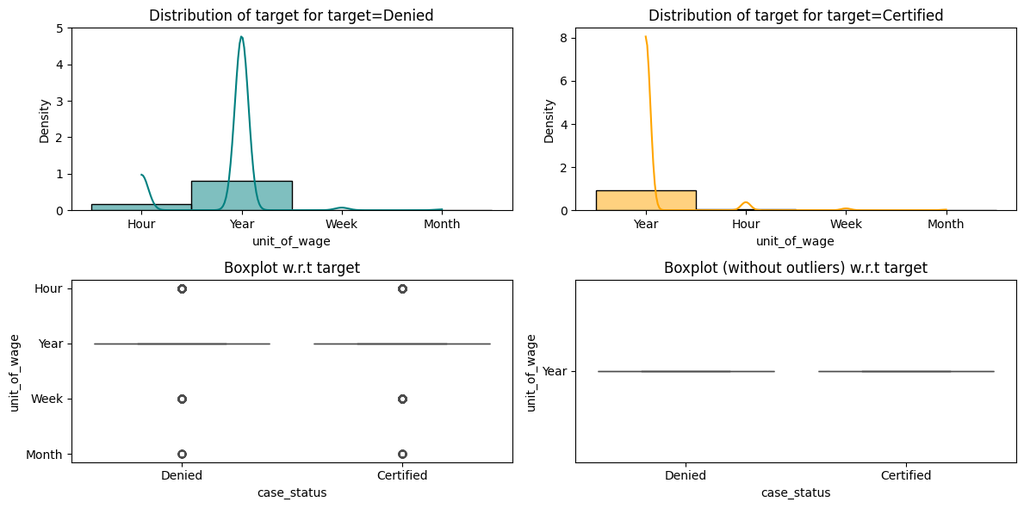

Distribution plot for case_status for predictor:full_time_position

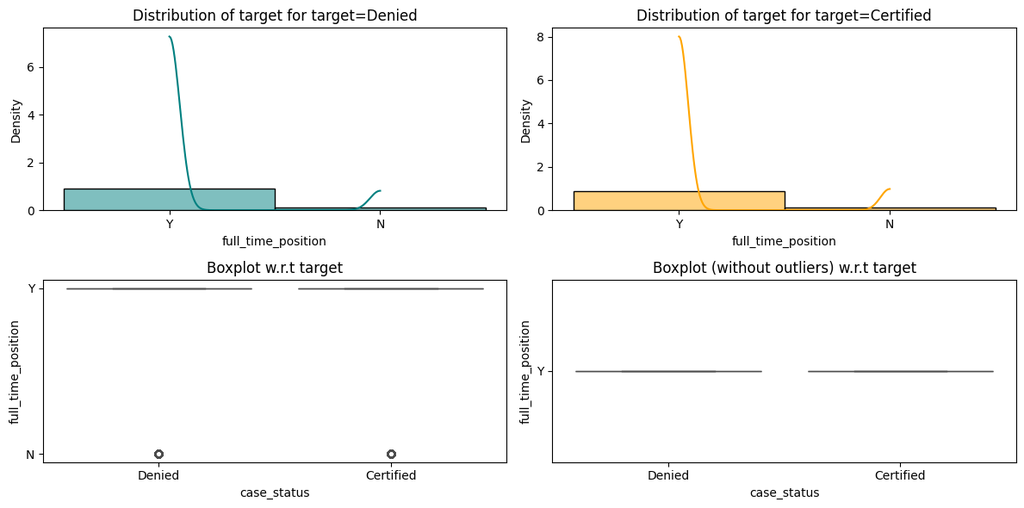

```python
EDA.distribution_plot_for_target_all(data=df, target="case_status", predictors=df.columns, figsize=(12, 6))
```

### Heatmap All

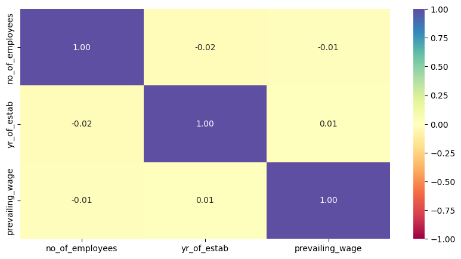

```python
cols_list = df.select_dtypes(include=np.number).columns.tolist()

plt.figure(figsize=(10, 5))
sns.heatmap(
    df[cols_list].corr(), annot=True, vmin=-1, vmax=1, fmt=".2f", cmap="Spectral"
)
plt.show()
```

## EDA Observations

1. What is the distribution of visa case statuses (certified vs. denied)?
- Approx 66% are certified vs 33% Denied.
2. How does the education level of employees impact visa approval rates?
- Higher education has better chances of getting certified. It is about 3 times more likely get visa certified if you have a doctorate than a highschool education.
3. Is there a significant difference in visa approval rates between employees with and without prior job experience?
- Employees with prior experience are more likely to get certified status by about 17% more.
4. How does the prevailing wage affect visa approval? Do higher wages lead to higher chances of approval?
- While the distributions overlap significantly, higher prevailing wages generally correlate with a higher likelihood of certification. The "Denied" cases have a slightly lower median and a more pronounced concentration of very low wage values, which may be a contributing factor to their denial (e.g., if the wage offered does not meet the actual prevailing wage for that specific occupation).
5. Do certain regions in the US have higher visa approval rates compared to others?
- Northeast & South Dominance: These two regions represent the bulk of the activity for both certified and denied cases.
- West : The West region shows a relatively high density in the "Denied" histogram compared to its density in the "Certified" histogram, suggesting a potentially higher risk of denial for applications in that region.
- Regional Concentration: Certified cases seem more geographically concentrated in the South and Northeast, while denials are more broadly spread across the West, Northeast, and South.
6. How does the number of employees in a company influence visa approval? Do larger companies have a higher approval rate?
- The relationship between the number of employees at a firm and the case status is heavily skewed by a few massive organizations.
- Extreme Skewness: The histograms show an incredibly high density of cases at the lower end of the employee count (small-to-medium businesses), with a "long tail" extending to nearly 600,000 employees.
7. Are visa approval rates different across various continents of employees? Which continent has the highest and lowest approval rates?
- Asia is the dominant source for both certified and denied visa applications.
- Dominant Group: Asia has the highest density by a significant margin for both "Denied" and "Certified" categories.
- Europe and North America show moderate density levels in both categories.
- Africa, South America, and Oceania represent a very small portion of the dataset.
- Statistical Distribution: The boxplots show that the median continent for both "Denied" and "Certified" cases is North America, with the interquartile range (IQR) extending up to Asia.

# **Data Pre-processing**

- Missing value treatment (if needed)
- Feature engineering (if needed)
- Outlier detection and treatment (if needed)
- Preparing data for modeling
- Any other preprocessing steps (if needed)

```python
df["case_status"] = df["case_status"].apply(lambda x: 1 if x == "Certified" else 0)

X = df.drop(["case_status"], axis=1)
y = df["case_status"]
X = pd.get_dummies(X, drop_first=True)

# Splitting data into training, validation and test sets
X_temp, X_test, y_temp, y_test = train_test_split(
    X, y, test_size=0.2, random_state=EDA.RANDOM_STATE, stratify=y
)

X_train, X_val, y_train, y_val = train_test_split(
    X_temp, y_temp, test_size=0.25, random_state=EDA.RANDOM_STATE, stratify=y_temp
)
```

```python
print(f"Training set : {X_train.shape}")
print(f"Validation set: {X_val.shape}")
print(f"Test set : {X_test.shape}")
print(f"Percentage of classes in training set: {y_train.value_counts(normalize=True)}")
print(f"Percentage of classes in validation set: {y_val.value_counts(normalize=True)}")
print(f"Percentage of classes in test set: {y_test.value_counts(normalize=True)}")
```

```
Training set : (15288, 21)
Validation set: (5096, 21)
Test set : (5096, 21)
Percentage of classes in training set: case_status
1    0.667909
0    0.332091
Name: proportion, dtype: float64
Percentage of classes in validation set: case_status
1    0.667779
0    0.332221
Name: proportion, dtype: float64
Percentage of classes in test set: case_status
1    0.667975
0    0.332025
Name: proportion, dtype: float64
```

### Observation

Based on the data distribution you provided, here is an analysis of your dataset split and class proportions:

**Split Proportions**: **60/20/20** split (approximately 15,288 training samples and 5,096 each for validation and testing). The most impressive part of your split is the **consistency of the target class (`case_status`)** across all three sets:

- **Training**: ~66.79% (Class 1) / ~33.21% (Class 0)
- **Validation**: ~66.78% (Class 1) / ~33.22% (Class 0)
- **Testing**: ~66.80% (Class 1) / ~33.20% (Class 0)

This has **Stratified Sampling**, a best practice because it ensures that each set is a "miniature version" of the original population, preventing a scenario where the model is tested on a distribution it never saw during training.

**Presence of Moderate Imbalance** Dataset is **moderately imbalanced**, with a 2:1 ratio (Class 1 is twice as common as Class 0):

# **Model Building**

### Lets build a function to show the graph of results.

```python
"""
# Build a function to show the graph of each model
"""
def showgraph(df_results, title):
    df_melted = df_results.melt(id_vars=['ModelName', 'Run'],
                        value_vars=['Accuracy', 'Recall', 'Precision', 'F1'],
                        var_name='Metric', value_name='Score')

    # Set visual style
    metrics = ['Accuracy', 'Recall', 'Precision', 'F1']
    fig, axes = plt.subplots(2, 2, figsize=(16, 12))
    axes = axes.flatten()

    sns.set_style("whitegrid")

    for i, metric in enumerate(metrics):
        # Assign the plot to a variable 'ax' to access its containers
        ax = sns.barplot(data=df_melted[df_melted['Metric'] == metric],
                        x='ModelName', y='Score', hue='Run', ax=axes[i], palette='viridis')

        # --- ADD VALUE LABELS HERE ---
        # Iterate through the bar containers (one for each 'Run')
        for container in ax.containers:
            ax.bar_label(container, fmt='%.3f', padding=3, fontsize=8, rotation=90)

        # -----------------------------

        axes[i].set_title(f'Model Comparison: {metric}', fontsize=8)
        axes[i].set_ylim(0, 1.2) # Increased limit slightly to fit labels on top
        axes[i].set_ylabel('Score')
        axes[i].set_xlabel('Model Name')
        axes[i].legend(title='Run', loc='lower right')
        axes[i].tick_params(axis='x', rotation=90)


    plt.tight_layout()
    plt.savefig(f'{title}.png')
    plt.show()
```

```python
# Setting up dataframe to store results
model_results = pd.DataFrame(columns=["Type","ModelName","Run", "Accuracy", "Recall", "Precision", "F1"])
models = []
```

### Models with Original Features and base models

```python
# Evaluating Original data models
models_original = []

# Adding models to the list
models_original.append(("Bagging", BaggingClassifier(estimator=DecisionTreeClassifier(random_state=EDA.RANDOM_STATE, class_weight='balanced'), random_state=EDA.RANDOM_STATE)))
models_original.append(("Randomforest", RandomForestClassifier(random_state=EDA.RANDOM_STATE, class_weight='balanced')))
models_original.append(("GradientBoost", GradientBoostingClassifier(random_state=EDA.RANDOM_STATE)))
models_original.append(("Adaboost", AdaBoostClassifier(random_state=EDA.RANDOM_STATE)))
models_original.append(("DecisionTree", DecisionTreeClassifier(random_state=EDA.RANDOM_STATE, class_weight='balanced')))

# Fitting and evaluating original data models
for name, model in models_original:
    model.fit(X_train, y_train)

    results = MLM.model_performance_classification(model, X_train, y_train)
    results["Type"] = "Original"
    results["ModelName"] = name
    results["Run"] = "Training"
    model_results = pd.concat([model_results, results], ignore_index=True)

    results = MLM.model_performance_classification(model, X_val, y_val)
    results["Type"] = "Original"
    results["ModelName"] = name
    results["Run"] = "Validation"
    model_results = pd.concat([model_results, results], ignore_index=True)

    results = MLM.model_performance_classification(model, X_test, y_test)
    results["Type"] = "Original"
    results["ModelName"] = name
    results["Run"] = "Testing"
    model_results = pd.concat([model_results, results], ignore_index=True)

models.append(models_original)
display(model_results)
```

|  | Type | ModelName | Run | Accuracy | Recall | Precision | F1 |
| --- | --- | --- | --- | --- | --- | --- | --- |
| 0 | Original | Bagging | Training | 0.984236 | 0.984820 | 0.991520 | 0.988159 |
| 1 | Original | Bagging | Validation | 0.703100 | 0.794887 | 0.768466 | 0.781453 |
| 2 | Original | Bagging | Testing | 0.691327 | 0.782315 | 0.761946 | 0.771996 |
| 3 | Original | Randomforest | Training | 0.999935 | 1.000000 | 0.999902 | 0.999951 |
| 4 | Original | Randomforest | Validation | 0.724686 | 0.850132 | 0.764131 | 0.804841 |
| 5 | Original | Randomforest | Testing | 0.722920 | 0.845182 | 0.764753 | 0.802958 |
| 6 | Original | GradientBoost | Training | 0.759288 | 0.878758 | 0.786071 | 0.829834 |
| 7 | Original | GradientBoost | Validation | 0.749608 | 0.878636 | 0.776019 | 0.824146 |
| 8 | Original | GradientBoost | Testing | 0.741954 | 0.873678 | 0.770666 | 0.818945 |
| 9 | Original | Adaboost | Training | 0.741497 | 0.884145 | 0.765279 | 0.820429 |
| 10 | Original | Adaboost | Validation | 0.738422 | 0.892154 | 0.758621 | 0.819986 |
| 11 | Original | Adaboost | Testing | 0.730181 | 0.881022 | 0.755606 | 0.813509 |
| 12 | Original | DecisionTree | Training | 1.000000 | 1.000000 | 1.000000 | 1.000000 |
| 13 | Original | DecisionTree | Validation | 0.655808 | 0.744637 | 0.741152 | 0.742891 |
| 14 | Original | DecisionTree | Testing | 0.662677 | 0.744418 | 0.749039 | 0.746722 |

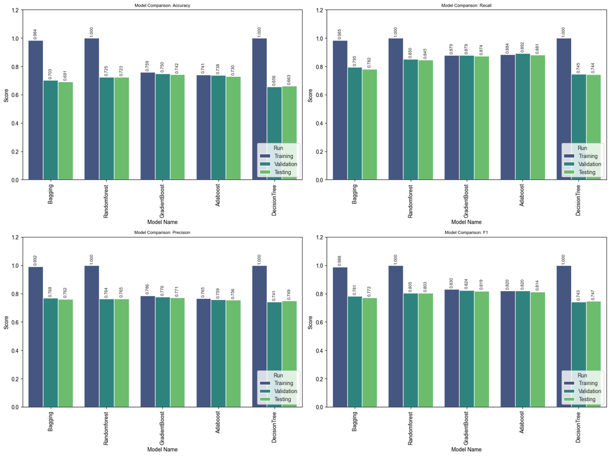

```python
showgraph(model_results[model_results["Type"] == "Original"], title="Model Comparison - Original Data")
```

### Observations

1. Overfitting: Models like DecisionTree and Randomforest have perfect or near-perfect training scores (1.0 or 0.99) but drop significantly on validation and testing (around 0.66–0.72). This suggests they are overfitting to the training data.
2. Generalization: GradientBoost and Adaboost show much more consistent scores across all runs (e.g., 0.75 training vs 0.74 testing), which indicates better generalization to new, unseen data.
3. Metrics Choice: While accuracy is common, for imbalanced datasets, you should prioritize the F1-score, which is the harmonic mean of precision and recall.

Model

1. GradientBoost- Best Overall Performer- The highest Testing Accuracy (0.7419) - least amount of "gap" between training and testing
2. Adaboost - Strong second place performer. Similar to GradientBoost- generalizes well- achieves the highest Recall on the Validation set (0.8921) - Good when positive cases is a priority.
3. Randomforest - Overfit - performs better on testing than a simple Decision Tree (0.7229 vs 0.6626), 0.999 training accuracy may suggest too complex model.
4. Bagging - Seems to be Overfitting - slightly worse than Random Forest across most metrics
5. DecisionTree - Worst Performer - perfect training scores (1.00) - lowest testing accuracy (0.6626)

## Model Building - Oversampled Data

```python
print("Before Oversampling, counts of label 'Certified': {}".format(sum(y_train == 1)))
print("Before Oversampling, counts of label 'Denied': {} \n".format(sum(y_train == 0)))

sm = SMOTE( sampling_strategy=1, k_neighbors=5, random_state=EDA.RANDOM_STATE)  # Synthetic Minority Over Sampling Technique
X_train_over, y_train_over = sm.fit_resample(X_train, y_train)


print("After Oversampling, counts of label 'Certified': {}".format(sum(y_train_over == 1)))
print("After Oversampling, counts of label 'Denied': {} \n".format(sum(y_train_over == 0)))


print("After Oversampling, the shape of train_X: {}".format(X_train_over.shape))
print("After Oversampling, the shape of train_y: {} \n".format(y_train_over.shape))
```

```
Before Oversampling, counts of label 'Certified': 10211
Before Oversampling, counts of label 'Denied': 5077

After Oversampling, counts of label 'Certified': 10211
After Oversampling, counts of label 'Denied': 10211

After Oversampling, the shape of train_X: (20422, 21)
After Oversampling, the shape of train_y: (20422,)
```

### Observations

The primary goal of SMOTE is to eliminate the bias toward the majority class by equalizing the number of samples:

- **Before SMOTE:** Dataset had a moderate imbalance with 10,211 'Certified' (67%) and 5,077 'Denied' (33%) cases.
- **After SMOTE:** Now have exactly **10,211** observations.
- **Result:** 50/50 distribution - prevents a "frequency bias"
- **Growth in Volume:** from 15,288 samples to **20,422** samples.
- **Synthetic Logic:** Created *new, synthetic* examples by interpolating between existing minority points.
- **Feature Preservation:** The shape of train_X remaining at **21 columns**

### Summary of the "After SMOTE" State

| Feature | Before SMOTE | After SMOTE |
| --- | --- | --- |
| **Certified Count** | 10,211 | 10,211 |
| **Denied Count** | 5,077 | 10,211 |
| **Total Rows** | 15,288 | 20,422 |
| **Class Ratio** | 2:1 (Imbalanced) | 1:1 (Balanced) |

```python
# Evaluating Oversampled data models
models_over = []

models_over.append(("Bagging", BaggingClassifier(estimator=DecisionTreeClassifier(random_state=EDA.RANDOM_STATE, class_weight='balanced'), random_state=EDA.RANDOM_STATE)))
models_over.append(("RandomForest", RandomForestClassifier(random_state=EDA.RANDOM_STATE, class_weight='balanced')))
models_over.append(("GradientBoost", GradientBoostingClassifier(random_state=EDA.RANDOM_STATE)))
models_over.append(("Adaboost", AdaBoostClassifier(random_state=EDA.RANDOM_STATE)))
models_over.append(("DecisionTree", DecisionTreeClassifier(random_state=EDA.RANDOM_STATE, class_weight='balanced')))

# Fitting and evaluating oversampled data models
for name, model in models_over:
    model.fit(X_train_over, y_train_over)

    results = MLM.model_performance_classification(model, X_train, y_train)
    results["Type"] = "OverSampled"
    results["ModelName"] = name
    results["Run"] = "Training"
    model_results = pd.concat([model_results, results], ignore_index=True)

    results = MLM.model_performance_classification(model, X_val, y_val)
    results["Type"] = "OverSampled"
    results["ModelName"] = name
    results["Run"] = "Validation"
    model_results = pd.concat([model_results, results], ignore_index=True)

    results = MLM.model_performance_classification(model, X_test, y_test)
    results["Type"] = "OverSampled"
    results["ModelName"] = name
    results["Run"] = "Testing"
    model_results = pd.concat([model_results, results], ignore_index=True)

models.append(models_over)
display(model_results[model_results["Type"] == "OverSampled"])
```

|  | Type | ModelName | Run | Accuracy | Recall | Precision | F1 |
| --- | --- | --- | --- | --- | --- | --- | --- |
| 15 | OverSampled | Bagging | Training | 0.982862 | 0.981686 | 0.992574 | 0.987100 |
| 16 | OverSampled | Bagging | Validation | 0.683477 | 0.751396 | 0.769254 | 0.760220 |
| 17 | OverSampled | Bagging | Testing | 0.679356 | 0.747356 | 0.766727 | 0.756918 |
| 18 | OverSampled | RandomForest | Training | 1.000000 | 1.000000 | 1.000000 | 1.000000 |
| 19 | OverSampled | RandomForest | Validation | 0.715267 | 0.819571 | 0.769167 | 0.793569 |
| 20 | OverSampled | RandomForest | Testing | 0.714286 | 0.813161 | 0.771460 | 0.791762 |
| 21 | OverSampled | GradientBoost | Training | 0.752551 | 0.857311 | 0.790072 | 0.822319 |
| 22 | OverSampled | GradientBoost | Validation | 0.744309 | 0.854246 | 0.782714 | 0.816917 |
| 23 | OverSampled | GradientBoost | Testing | 0.734890 | 0.850470 | 0.774686 | 0.810811 |
| 24 | OverSampled | Adaboost | Training | 0.741039 | 0.879542 | 0.766951 | 0.819397 |
| 25 | OverSampled | Adaboost | Validation | 0.739796 | 0.883338 | 0.763914 | 0.819297 |
| 26 | OverSampled | Adaboost | Testing | 0.730377 | 0.876322 | 0.757876 | 0.812807 |
| 27 | OverSampled | DecisionTree | Training | 1.000000 | 1.000000 | 1.000000 | 1.000000 |
| 28 | OverSampled | DecisionTree | Validation | 0.649725 | 0.729356 | 0.741781 | 0.735516 |
| 29 | OverSampled | DecisionTree | Testing | 0.632261 | 0.708872 | 0.732100 | 0.720299 |

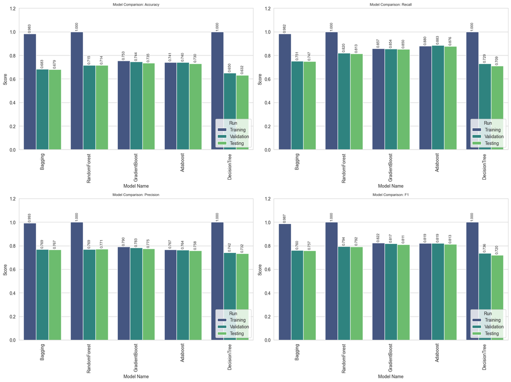

```python
showgraph(model_results[model_results["Type"] == "OverSampled"], title="Model Comparison OverSampled")
```

## Model Building - Undersampled Data

```python
# Evaluating Undersampled data models
rus = RandomUnderSampler(random_state=EDA.RANDOM_STATE)
X_train_under, y_train_under = rus.fit_resample(X_train, y_train)
```

```python
print("Before Under Sampling, counts of label 'Certified': {}".format(sum(y_train == 1)))
print("Before Under Sampling, counts of label 'Denied': {} \n".format(sum(y_train == 0)))

print("After Under Sampling, counts of label 'Certified': {}".format(sum(y_train_under == 1)))
print("After Under Sampling, counts of label 'Denied': {} \n".format(sum(y_train_under == 0)))

print("After Under Sampling, the shape of train_X: {}".format(X_train_under.shape))
print("After Under Sampling, the shape of train_y: {} \n".format(y_train_under.shape))
```

```
Before Under Sampling, counts of label 'Certified': 10211
Before Under Sampling, counts of label 'Denied': 5077

After Under Sampling, counts of label 'Certified': 5077
After Under Sampling, counts of label 'Denied': 5077

After Under Sampling, the shape of train_X: (10154, 21)
After Under Sampling, the shape of train_y: (10154,)
```

```python
# Evaluating Undersampled data models
models_under = []  # Empty list to store all the models
# Adding models to the list
models_under.append(("Bagging", BaggingClassifier(estimator=DecisionTreeClassifier(random_state=EDA.RANDOM_STATE, class_weight='balanced'), random_state=EDA.RANDOM_STATE)))
models_under.append(("RandomForest", RandomForestClassifier(random_state=EDA.RANDOM_STATE, class_weight='balanced')))
models_under.append(("GradientBoost", GradientBoostingClassifier(random_state=EDA.RANDOM_STATE)))
models_under.append(("Adaboost", AdaBoostClassifier(random_state=EDA.RANDOM_STATE)))
models_under.append(("DecisionTree", DecisionTreeClassifier(random_state=EDA.RANDOM_STATE, class_weight='balanced')))


for name, model in models_under:
    model.fit(X_train_under, y_train_under)

    results = MLM.model_performance_classification(model, X_train, y_train)
    results["Type"] = "UnderSampled"
    results["ModelName"] = name
    results["Run"] = "Training"
    model_results = pd.concat([model_results, results], ignore_index=True)

    results = MLM.model_performance_classification(model, X_val, y_val)
    results["Type"] = "UnderSampled"
    results["ModelName"] = name
    results["Run"] = "Validation"
    model_results = pd.concat([model_results, results], ignore_index=True)

    results = MLM.model_performance_classification(model, X_test, y_test)
    results["Type"] = "UnderSampled"
    results["ModelName"] = name
    results["Run"] = "Testing"
    model_results = pd.concat([model_results, results], ignore_index=True)

models.append(models_under)
model_results[model_results["Type"] == "UnderSampled"]
```

|  | Type | ModelName | Run | Accuracy | Recall | Precision | F1 |
| --- | --- | --- | --- | --- | --- | --- | --- |
| 30 | UnderSampled | Bagging | Training | 0.857339 | 0.790716 | 0.994580 | 0.881008 |
| 31 | UnderSampled | Bagging | Validation | 0.646193 | 0.611225 | 0.812500 | 0.697635 |
| 32 | UnderSampled | Bagging | Testing | 0.639129 | 0.603114 | 0.807950 | 0.690664 |
| 33 | UnderSampled | RandomForest | Training | 0.894231 | 0.841641 | 1.000000 | 0.914012 |
| 34 | UnderSampled | RandomForest | Validation | 0.683477 | 0.683808 | 0.812500 | 0.742620 |
| 35 | UnderSampled | RandomForest | Testing | 0.671507 | 0.671857 | 0.804149 | 0.732074 |
| 36 | UnderSampled | GradientBoost | Training | 0.729265 | 0.742141 | 0.834214 | 0.785488 |
| 37 | UnderSampled | GradientBoost | Validation | 0.716837 | 0.736703 | 0.820891 | 0.776522 |
| 38 | UnderSampled | GradientBoost | Testing | 0.697998 | 0.717685 | 0.808673 | 0.760467 |
| 39 | UnderSampled | Adaboost | Training | 0.707941 | 0.740574 | 0.806355 | 0.772066 |
| 40 | UnderSampled | Adaboost | Validation | 0.709380 | 0.748751 | 0.802773 | 0.774821 |
| 41 | UnderSampled | Adaboost | Testing | 0.688579 | 0.727086 | 0.789978 | 0.757228 |
| 42 | UnderSampled | DecisionTree | Training | 0.869963 | 0.805308 | 1.000000 | 0.892156 |
| 43 | UnderSampled | DecisionTree | Validation | 0.614600 | 0.611813 | 0.764037 | 0.679504 |
| 44 | UnderSampled | DecisionTree | Testing | 0.621075 | 0.615746 | 0.770872 | 0.684632 |

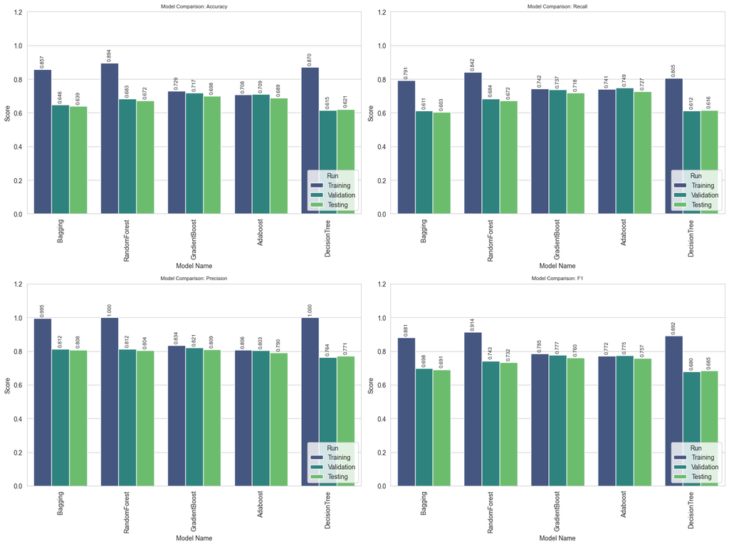

```python
showgraph(model_results[model_results["Type"] == "UnderSampled"], title="Model Comparison UnderSampled Data")
```

## Oversampling vs undersampling comparision

```python
model_results[((model_results["Type"] == "UnderSampled") | (model_results["Type"] == "OverSampled"))
    & ((model_results["Run"] == "Testing") | (model_results["Run"] == "Validation"))].sort_values(by=["F1"], ascending=False)
```

|  | Type | ModelName | Run | Accuracy | Recall | Precision | F1 |
| --- | --- | --- | --- | --- | --- | --- | --- |
| 25 | OverSampled | Adaboost | Validation | 0.739796 | 0.883338 | 0.763914 | 0.819297 |
| 22 | OverSampled | GradientBoost | Validation | 0.744309 | 0.854246 | 0.782714 | 0.816917 |
| 26 | OverSampled | Adaboost | Testing | 0.730377 | 0.876322 | 0.757876 | 0.812807 |
| 23 | OverSampled | GradientBoost | Testing | 0.734890 | 0.850470 | 0.774686 | 0.810811 |
| 19 | OverSampled | RandomForest | Validation | 0.715267 | 0.819571 | 0.769167 | 0.793569 |
| 20 | OverSampled | RandomForest | Testing | 0.714286 | 0.813161 | 0.771460 | 0.791762 |
| 37 | UnderSampled | GradientBoost | Validation | 0.716837 | 0.736703 | 0.820891 | 0.776522 |
| 40 | UnderSampled | Adaboost | Validation | 0.709380 | 0.748751 | 0.802773 | 0.774821 |
| 38 | UnderSampled | GradientBoost | Testing | 0.697998 | 0.717685 | 0.808673 | 0.760467 |
| 16 | OverSampled | Bagging | Validation | 0.683477 | 0.751396 | 0.769254 | 0.760220 |
| 41 | UnderSampled | Adaboost | Testing | 0.688579 | 0.727086 | 0.789978 | 0.757228 |
| 17 | OverSampled | Bagging | Testing | 0.679356 | 0.747356 | 0.766727 | 0.756918 |
| 34 | UnderSampled | RandomForest | Validation | 0.683477 | 0.683808 | 0.812500 | 0.742620 |
| 28 | OverSampled | DecisionTree | Validation | 0.649725 | 0.729356 | 0.741781 | 0.735516 |
| 35 | UnderSampled | RandomForest | Testing | 0.671507 | 0.671857 | 0.804149 | 0.732074 |
| 29 | OverSampled | DecisionTree | Testing | 0.632261 | 0.708872 | 0.732100 | 0.720299 |
| 31 | UnderSampled | Bagging | Validation | 0.646193 | 0.611225 | 0.812500 | 0.697635 |
| 32 | UnderSampled | Bagging | Testing | 0.639129 | 0.603114 | 0.807950 | 0.690664 |
| 44 | UnderSampled | DecisionTree | Testing | 0.621075 | 0.615746 | 0.770872 | 0.684632 |
| 43 | UnderSampled | DecisionTree | Validation | 0.614600 | 0.611813 | 0.764037 | 0.679504 |

#### Observations

This comprehensive analysis evaluates the performance of 5 models—**Adaboost, GradientBoost, RandomForest, Bagging, and DecisionTree**—trained using two different resampling techniques (**OverSampling** and **UnderSampling**).

#### Overall Performance Leaders (F1-Score)

- The **F1-Score** is a reliable metric here as it balances Precision and Recall for an imbalanced dataset.
- The results consistently show that **Boosting** algorithms (Adaboost and GradientBoost) combined with **OverSampling** are the better performers.
- **Best Overall Model:** **OverSampled Adaboost** achieved the highest Testing F1-score (**0.8128**) and the highest Testing Recall (**0.8763**).
- **Best Accuracy:** **OverSampled GradientBoost** provided the most balanced results with the highest Testing Accuracy (**0.7349**) and a very strong F1-score (**0.8108**).

#### Generalization Analysis (Validation vs. Testing)

- **Adaboost (OverSampled):** F1 dropped only **0.0065** (from 0.8193 to 0.8128).
- **GradientBoost (OverSampled):** F1 dropped only **0.0061** (from 0.8169 to 0.8108).
- **DecisionTree (UnderSampled):** Remained the least stable, showing the lowest performance across the board.

#### Summary Table of Top Testing Performers

The table below ranks the top 5 model configurations based on their Testing set F1-Scores:

| Rank | Model Name | Technique | Accuracy | Recall | Precision | F1-Score |
| --- | --- | --- | --- | --- | --- | --- |
| **1** | **Adaboost** | **OverSampled** | 0.7303 | **0.8763** | 0.7578 | **0.8128** |
| **2** | **GradientBoost** | **OverSampled** | **0.7348** | 0.8504 | 0.7746 | **0.8108** |
| **3** | **RandomForest** | **OverSampled** | 0.7142 | 0.8131 | 0.7714 | 0.7917 |
| **4** | **GradientBoost** | **UnderSampled** | 0.6979 | 0.7176 | **0.8086** | 0.7604 |
| **5** | **Adaboost** | **UnderSampled** | 0.6885 | 0.7270 | 0.7899 | 0.7572 |

#### Recommendations

# **Model Performance Improvement**

### **Note** - Using the parameters provided to hypertune.

1. Sample parameter grids have been provided to do necessary hyperparameter tuning. These sample grids are expected to provide a balance between model performance improvement and execution time. One can extend/reduce the parameter grid based on execution time and system configuration.
- Please note that if the parameter grid is extended to improve the model performance further, the execution time will increase
2. The models chosen in this notebook are based on test runs. One can update the best models as obtained upon code execution and tune them for best performance.
- For Gradient Boosting:

  ```
  param_grid = {
      "init": [AdaBoostClassifier(random_state=1),DecisionTreeClassifier(random_state=1)],
      "n_estimators": np.arange(50,110,25),
      "learning_rate": [0.01,0.1,0.05],
      "subsample":[0.7,0.9],
      "max_features":[0.5,0.7,1],
  }
  ```

- For Adaboost:

  ```
  param_grid = {
      "n_estimators": np.arange(50,110,25),
      "learning_rate": [0.01,0.1,0.05],
      "base_estimator": [
          DecisionTreeClassifier(max_depth=2, random_state=1),
          DecisionTreeClassifier(max_depth=3, random_state=1),
      ],
  }
  ```

- For Bagging Classifier:

  ````
      param_grid = {
          'max_samples': [0.8,0.9,1],
          'max_features': [0.7,0.8,0.9],
          'n_estimators' : [30,50,70],
      }
      ```
  ````

- For Random Forest:

  ```
  param_grid = {
      "n_estimators": [50,110,25],
      "min_samples_leaf": np.arange(1, 4),
      "max_features": [np.arange(0.3, 0.6, 0.1),'sqrt'],
      "max_samples": np.arange(0.4, 0.7, 0.1)
  }
  ```

- For Decision Trees:

  ```
  param_grid = {
      'max_depth': np.arange(2,6),
      'min_samples_leaf': [1, 4, 7],
      'max_leaf_nodes' : [10, 15],
      'min_impurity_decrease': [0.0001,0.001]
  }
  ```

- For XGBoost:

  ```
  param_grid={
      'n_estimators':np.arange(50,110,25),
      'scale_pos_weight':[1,2,5],
      'learning_rate':[0.01,0.1,0.05],
      'gamma':[1,3],
      'subsample':[0.7,0.9]
  }
  ```

## Hyperparameter Tuning - Random Forest

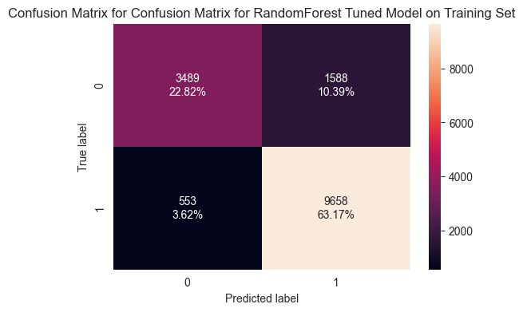

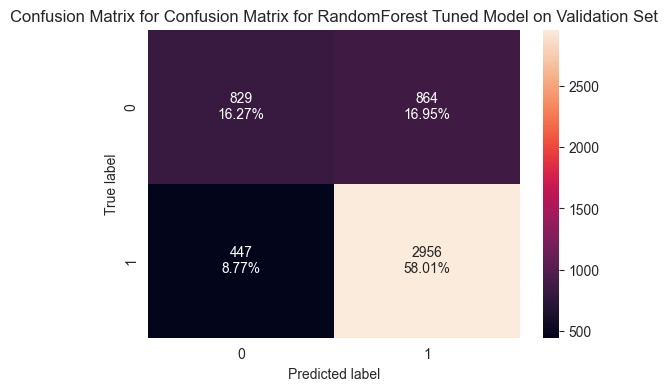

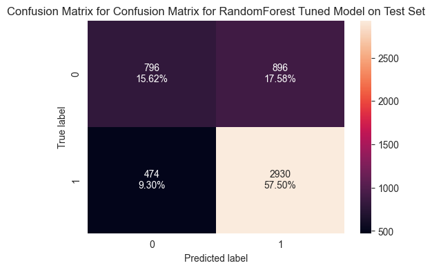

|  | Feature | Importance |
| --- | --- | --- |
| 2 | prevailing_wage | 0.233268 |
| 0 | no_of_employees | 0.195937 |
| 1 | yr_of_estab | 0.165776 |
| 9 | education_of_employee_High School | 0.102012 |
| 11 | has_job_experience_Y | 0.068482 |
| 10 | education_of_employee_Master's | 0.047405 |
| 19 | unit_of_wage_Year | 0.025162 |
| 8 | education_of_employee_Doctorate | 0.022031 |
| 4 | continent_Europe | 0.020595 |
| 20 | full_time_position_Y | 0.015405 |
| 12 | requires_job_training_Y | 0.014553 |
| 3 | continent_Asia | 0.014349 |
| 13 | region_of_employment_Midwest | 0.013738 |
| 15 | region_of_employment_South | 0.012995 |
| 16 | region_of_employment_West | 0.012819 |
| 5 | continent_North America | 0.012348 |
| 14 | region_of_employment_Northeast | 0.012072 |
| 7 | continent_South America | 0.006344 |
| 18 | unit_of_wage_Week | 0.002300 |
| 6 | continent_Oceania | 0.001795 |
| 17 | unit_of_wage_Month | 0.000616 |

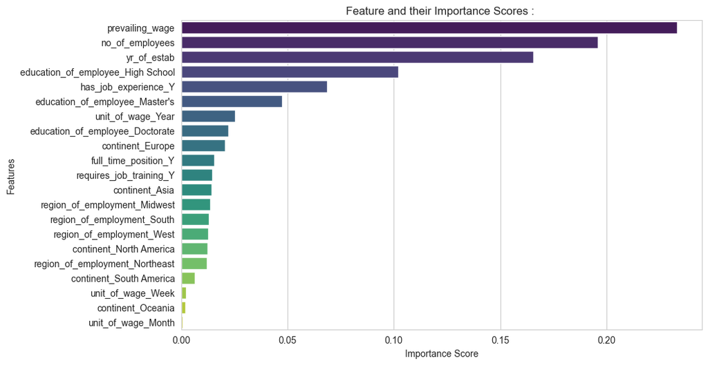

```
CPU times: user 4.77 s, sys: 2.28 s, total: 7.05 s
Wall time: 18.4 s
```

```python
%%time
# Choose the type of classifier.
randomforrest_tuned = RandomForestClassifier(random_state=EDA.RANDOM_STATE, oob_score=True, bootstrap=True)

parameters = {
    "n_estimators": [50,110,25],
    "min_samples_leaf": np.arange(1, 4),
    "max_features": [np.arange(0.3, 0.6, 0.1),'sqrt'],
    "max_samples": np.arange(0.4, 0.7, 0.1)
}

# Type of scoring used to compare parameter combinations
acc_scorer = metrics.make_scorer(metrics.f1_score)

# Run the grid search
grid_obj = GridSearchCV(randomforrest_tuned, parameters, scoring=acc_scorer, cv=5, n_jobs=-1)
grid_obj = grid_obj.fit(X_train_over, y_train_over)

# Set the clf to the best combination of parameters
randomforrest_tuned = grid_obj.best_estimator_

# Fit the best algorithm to the data.
randomforrest_tuned.fit(X_train, y_train)

results = MLM.model_performance_classification(randomforrest_tuned, X_train, y_train)
results["Type"] = "OverTuned"
results["ModelName"] = "RandomForestTuned"
results["Run"] = "Training"
model_results = pd.concat([model_results, results], ignore_index=True)

results = MLM.model_performance_classification(randomforrest_tuned, X_val, y_val)
results["Type"] = "OverTuned"
results["ModelName"] = "RandomForestTuned"
results["Run"] = "Validation"
model_results = pd.concat([model_results, results], ignore_index=True)

results = MLM.model_performance_classification(randomforrest_tuned, X_test, y_test)
results["Type"] = "OverTuned"
results["ModelName"] = "RandomForestTuned"
results["Run"] = "Testing"
model_results = pd.concat([model_results, results], ignore_index=True)

models.append(("RandomForestTuned", randomforrest_tuned))


MLM.plot_confusion_matrix(model=randomforrest_tuned, predictors=X_train, expected=y_train,
                            title="Confusion Matrix for RandomForest Tuned Model on Training Set")
MLM.plot_confusion_matrix(model=randomforrest_tuned, predictors=X_val, expected=y_val,
                            title="Confusion Matrix for RandomForest Tuned Model on Validation Set")
MLM.plot_confusion_matrix(model=randomforrest_tuned, predictors=X_test, expected=y_test,
                            title="Confusion Matrix for RandomForest Tuned Model on Test Set")

MLM.plot_feature_importance(model=randomforrest_tuned, features=X_train.columns)
```

|  | Type | ModelName | Run | Accuracy | Recall | Precision | F1 |
| --- | --- | --- | --- | --- | --- | --- | --- |
| 45 | OverTuned | RandomForestTuned | Training | 0.859956 | 0.945843 | 0.858794 | 0.900219 |
| 46 | OverTuned | RandomForestTuned | Validation | 0.742739 | 0.868645 | 0.773822 | 0.818496 |
| 47 | OverTuned | RandomForestTuned | Testing | 0.731162 | 0.860752 | 0.765813 | 0.810512 |

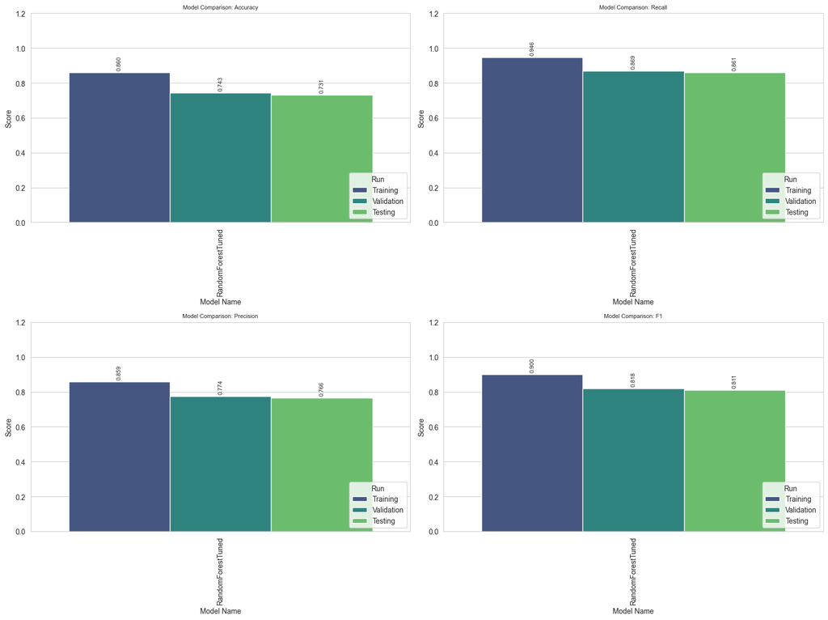

```python
display(model_results[model_results["Type"] == "OverTuned"])
showgraph(model_results[model_results["Type"] == "OverTuned"], title="Model Comparison Oversampled Tuned Data")
```

## Hyperparameter Tuning - AdaBoost Classifier

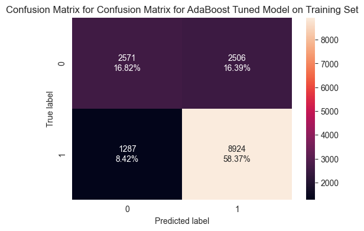

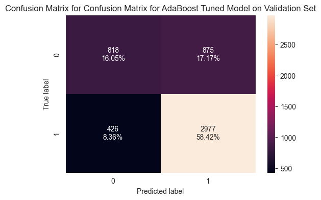

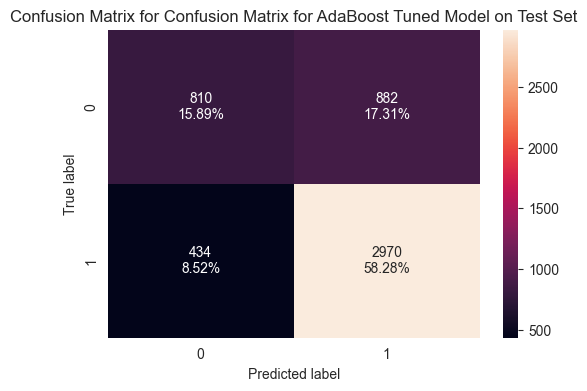

|  | Feature | Importance |
| --- | --- | --- |
| 11 | has_job_experience_Y | 0.257532 |
| 10 | education_of_employee_Master's | 0.174589 |
| 9 | education_of_employee_High School | 0.125750 |
| 8 | education_of_employee_Doctorate | 0.124028 |
| 4 | continent_Europe | 0.077060 |
| 2 | prevailing_wage | 0.073065 |
| 19 | unit_of_wage_Year | 0.045636 |
| 13 | region_of_employment_Midwest | 0.038162 |
| 12 | requires_job_training_Y | 0.027358 |
| 15 | region_of_employment_South | 0.013136 |
| 0 | no_of_employees | 0.012090 |
| 5 | continent_North America | 0.008409 |
| 20 | full_time_position_Y | 0.007335 |
| 1 | yr_of_estab | 0.007208 |
| 16 | region_of_employment_West | 0.003163 |
| 3 | continent_Asia | 0.003120 |
| 7 | continent_South America | 0.002238 |
| 14 | region_of_employment_Northeast | 0.000121 |
| 6 | continent_Oceania | 0.000000 |
| 17 | unit_of_wage_Month | 0.000000 |
| 18 | unit_of_wage_Week | 0.000000 |

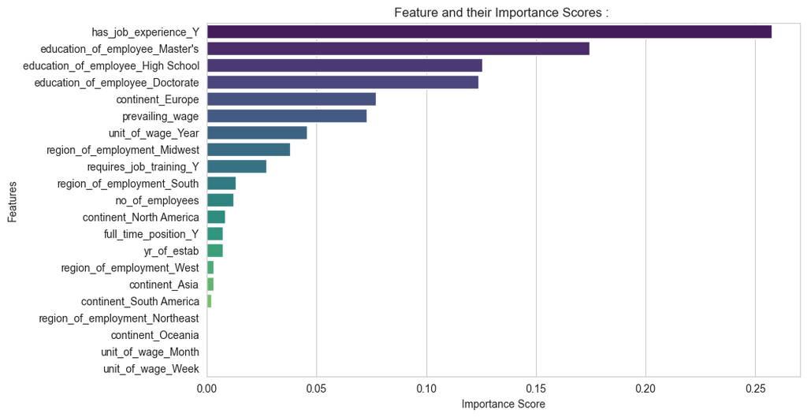

```
CPU times: user 5.27 s, sys: 242 ms, total: 5.51 s
Wall time: 18.4 s
```

```python
%%time
# Choose the type of classifier.
adaboost_tuned = AdaBoostClassifier(random_state=EDA.RANDOM_STATE)

# Grid of parameters to choose from
parameters = {
    "n_estimators": np.arange(50,110,25),
    "learning_rate": [0.01,0.1,0.05],
    "estimator": [
        DecisionTreeClassifier(max_depth=2, random_state=EDA.RANDOM_STATE),
        DecisionTreeClassifier(max_depth=3, random_state=EDA.RANDOM_STATE),
    ],
}

# Type of scoring used to compare parameter combinations
acc_scorer = metrics.make_scorer(metrics.f1_score)

# Run the grid search
grid_obj = GridSearchCV(adaboost_tuned, parameters, scoring=acc_scorer, cv=5, n_jobs=-1)
grid_obj = grid_obj.fit(X_train_over, y_train_over)


# Set the clf to the best combination of parameters
adaboost_tuned = grid_obj.best_estimator_

# Fit the best algorithm to the data.
adaboost_tuned.fit(X_train, y_train)

results = MLM.model_performance_classification(adaboost_tuned, X_train, y_train)
results["Type"] = "OverTuned"
results["ModelName"] = "AdaBoostTuned"
results["Run"] = "Training"
model_results = pd.concat([model_results, results], ignore_index=True)

results = MLM.model_performance_classification(adaboost_tuned, X_val, y_val)
results["Type"] = "OverTuned"
results["ModelName"] = "AdaBoostTuned"
results["Run"] = "Validation"
model_results = pd.concat([model_results, results], ignore_index=True)

results = MLM.model_performance_classification(adaboost_tuned, X_test, y_test)
results["Type"] = "OverTuned"
results["ModelName"] = "AdaBoostTuned"
results["Run"] = "Testing"
model_results = pd.concat([model_results, results], ignore_index=True)

models.append(("AdaBoostTuned", adaboost_tuned))


MLM.plot_confusion_matrix(model=adaboost_tuned, predictors=X_train, expected=y_train,
                            title="Confusion Matrix for AdaBoost Tuned Model on Training Set")
MLM.plot_confusion_matrix(model=adaboost_tuned, predictors=X_val, expected=y_val,
                            title="Confusion Matrix for AdaBoost Tuned Model on Validation Set")
MLM.plot_confusion_matrix(model=adaboost_tuned, predictors=X_test, expected=y_test,
                            title="Confusion Matrix for AdaBoost Tuned Model on Test Set")

MLM.plot_feature_importance(model=adaboost_tuned, features=X_train.columns)
```

|  | Type | ModelName | Run | Accuracy | Recall | Precision | F1 |
| --- | --- | --- | --- | --- | --- | --- | --- |
| 45 | OverTuned | RandomForestTuned | Training | 0.859956 | 0.945843 | 0.858794 | 0.900219 |
| 46 | OverTuned | RandomForestTuned | Validation | 0.742739 | 0.868645 | 0.773822 | 0.818496 |
| 47 | OverTuned | RandomForestTuned | Testing | 0.731162 | 0.860752 | 0.765813 | 0.810512 |
| 48 | OverTuned | AdaBoostTuned | Training | 0.751897 | 0.873959 | 0.780752 | 0.824731 |
| 49 | OverTuned | AdaBoostTuned | Validation | 0.744702 | 0.874816 | 0.772845 | 0.820675 |
| 50 | OverTuned | AdaBoostTuned | Testing | 0.741758 | 0.872503 | 0.771028 | 0.818633 |

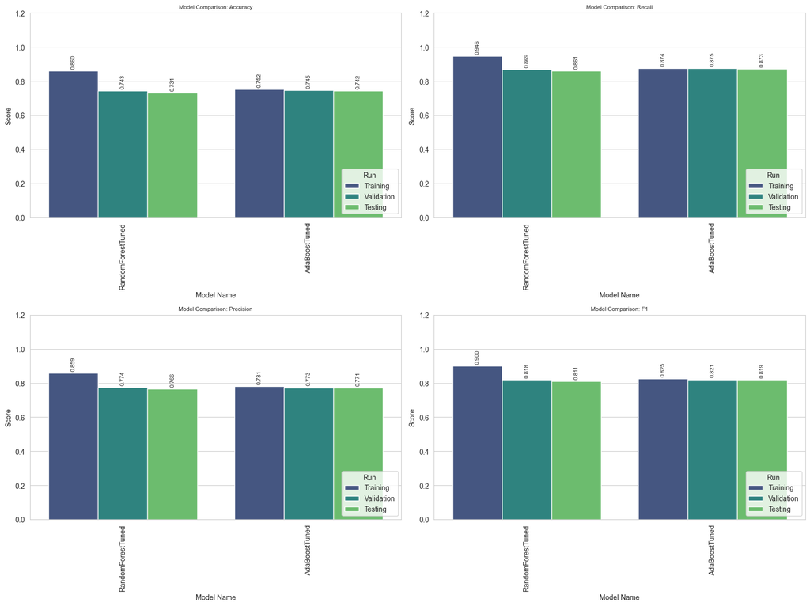

```python
display(model_results[model_results["Type"] == "OverTuned"])
showgraph(model_results[model_results["Type"] == "OverTuned"], title="Model Comparison Oversampled Tuned Data")
```

## Hyperparameter Tuning - Gradient Boosting Classifier

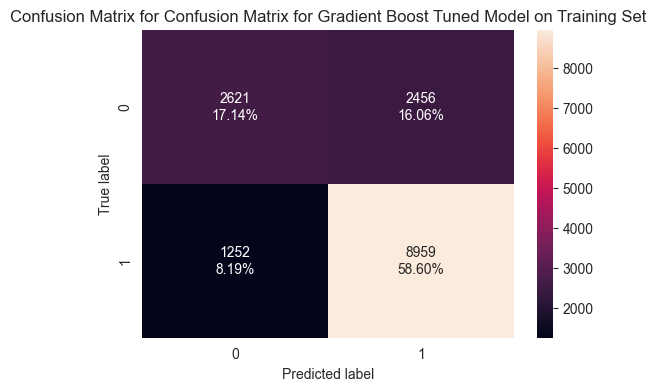

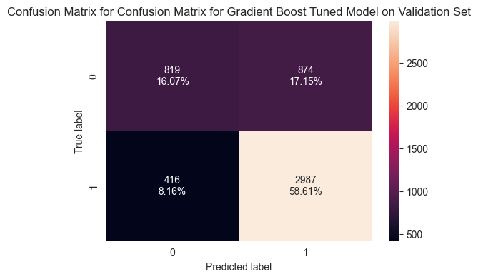

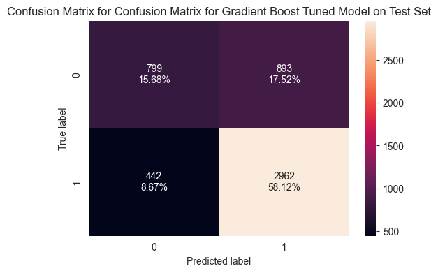

|  | Feature | Importance |
| --- | --- | --- |
| 9 | education_of_employee_High School | 0.176995 |
| 2 | prevailing_wage | 0.130845 |
| 11 | has_job_experience_Y | 0.118575 |
| 0 | no_of_employees | 0.084129 |
| 19 | unit_of_wage_Year | 0.079396 |
| 10 | education_of_employee_Master's | 0.075076 |
| 4 | continent_Europe | 0.074848 |
| 1 | yr_of_estab | 0.044543 |
| 8 | education_of_employee_Doctorate | 0.042124 |
| 13 | region_of_employment_Midwest | 0.031882 |
| 5 | continent_North America | 0.030542 |
| 16 | region_of_employment_West | 0.021269 |
| 3 | continent_Asia | 0.016544 |
| 12 | requires_job_training_Y | 0.015204 |
| 7 | continent_South America | 0.015014 |
| 15 | region_of_employment_South | 0.014525 |
| 14 | region_of_employment_Northeast | 0.012610 |
| 20 | full_time_position_Y | 0.006355 |
| 18 | unit_of_wage_Week | 0.005046 |
| 17 | unit_of_wage_Month | 0.002973 |
| 6 | continent_Oceania | 0.001505 |

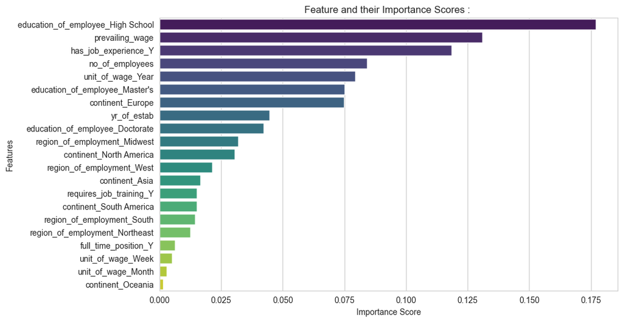

```
CPU times: user 5.12 s, sys: 556 ms, total: 5.67 s
Wall time: 59.7 s
```

```python
%%time
# Choose the type of classifier.
gradientboost_tuned = GradientBoostingClassifier(init=AdaBoostClassifier(random_state=EDA.RANDOM_STATE), random_state=EDA.RANDOM_STATE)

# Grid of parameters to choose from
parameters = {
    "init": [AdaBoostClassifier(random_state=1),DecisionTreeClassifier(random_state=1)],
    "n_estimators": np.arange(50,110,25),
    "learning_rate": [0.01,0.1,0.05],
    "subsample":[0.7,0.9],
    "max_features":[0.5,0.7,1],
}

# Type of scoring used to compare parameter combinations
acc_scorer = metrics.make_scorer(metrics.f1_score)

# Run the grid search
grid_obj = GridSearchCV(gradientboost_tuned, parameters, scoring=acc_scorer, cv=5, n_jobs=-1)
grid_obj = grid_obj.fit(X_train_over, y_train_over)


# Set the clf to the best combination of parameters
gradientboost_tuned = grid_obj.best_estimator_

# Fit the best algorithm to the data.
gradientboost_tuned.fit(X_train, y_train)

results = MLM.model_performance_classification(gradientboost_tuned, X_train, y_train)
results["Type"] = "OverTuned"
results["ModelName"] = "GradientBoostTuned"
results["Run"] = "Training"
model_results = pd.concat([model_results, results], ignore_index=True)

results = MLM.model_performance_classification(gradientboost_tuned, X_val, y_val)
results["Type"] = "OverTuned"
results["ModelName"] = "GradientBoostTuned"
results["Run"] = "Validation"
model_results = pd.concat([model_results, results], ignore_index=True)

results = MLM.model_performance_classification(gradientboost_tuned, X_test, y_test)
results["Type"] = "OverTuned"
results["ModelName"] = "GradientBoostTuned"
results["Run"] = "Testing"
model_results = pd.concat([model_results, results], ignore_index=True)

models.append(("GradientBoostTuned", gradientboost_tuned))

MLM.plot_confusion_matrix(model=gradientboost_tuned, predictors=X_train, expected=y_train,
                            title="Confusion Matrix for Gradient Boost Tuned Model on Training Set")
MLM.plot_confusion_matrix(model=gradientboost_tuned, predictors=X_val, expected=y_val,
                            title="Confusion Matrix for Gradient Boost Tuned Model on Validation Set")
MLM.plot_confusion_matrix(model=gradientboost_tuned, predictors=X_test, expected=y_test,
                            title="Confusion Matrix for Gradient Boost Tuned Model on Test Set")

MLM.plot_feature_importance(model=gradientboost_tuned, features=X_train.columns)
```

|  | Type | ModelName | Run | Accuracy | Recall | Precision | F1 |
| --- | --- | --- | --- | --- | --- | --- | --- |
| 45 | OverTuned | RandomForestTuned | Training | 0.859956 | 0.945843 | 0.858794 | 0.900219 |
| 46 | OverTuned | RandomForestTuned | Validation | 0.742739 | 0.868645 | 0.773822 | 0.818496 |
| 47 | OverTuned | RandomForestTuned | Testing | 0.731162 | 0.860752 | 0.765813 | 0.810512 |
| 48 | OverTuned | AdaBoostTuned | Training | 0.751897 | 0.873959 | 0.780752 | 0.824731 |
| 49 | OverTuned | AdaBoostTuned | Validation | 0.744702 | 0.874816 | 0.772845 | 0.820675 |
| 50 | OverTuned | AdaBoostTuned | Testing | 0.741758 | 0.872503 | 0.771028 | 0.818633 |
| 51 | OverTuned | GradientBoostTuned | Training | 0.757457 | 0.877387 | 0.784845 | 0.828540 |
| 52 | OverTuned | GradientBoostTuned | Validation | 0.746860 | 0.877755 | 0.773634 | 0.822412 |
| 53 | OverTuned | GradientBoostTuned | Testing | 0.738030 | 0.870153 | 0.768353 | 0.816090 |

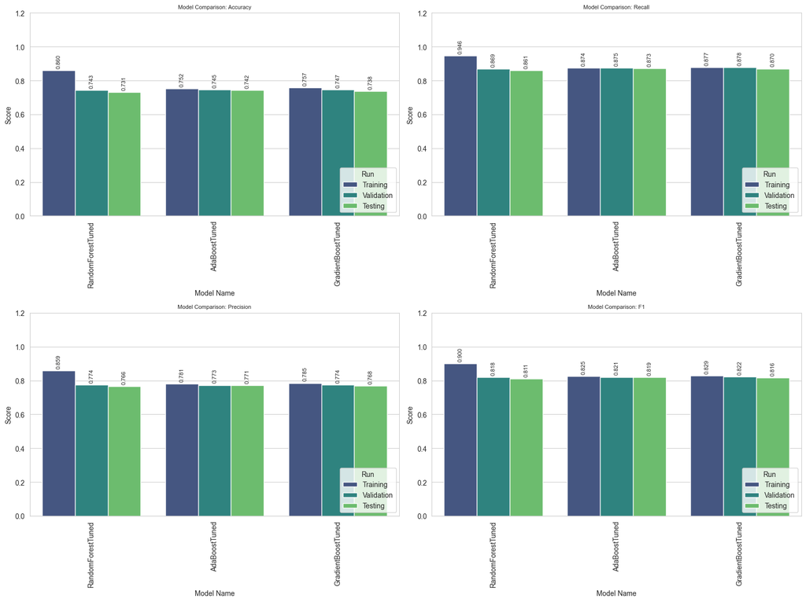

```python
display(model_results[model_results["Type"] == "OverTuned"])
showgraph(model_results[model_results["Type"] == "OverTuned"].sort_values(by="Type", ascending=False), title="Model Comparison Oversampled Tuned Data")
```

## Hyperparameter Tuning - XGBoost Classifier

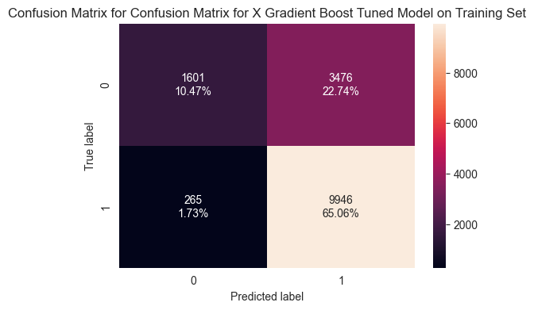

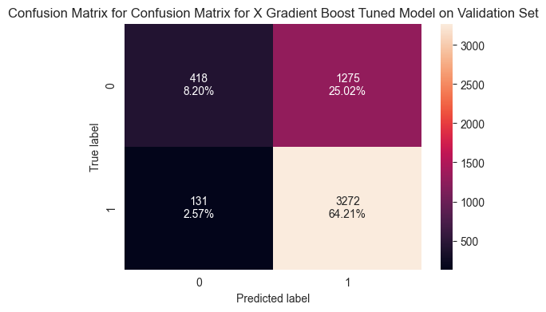

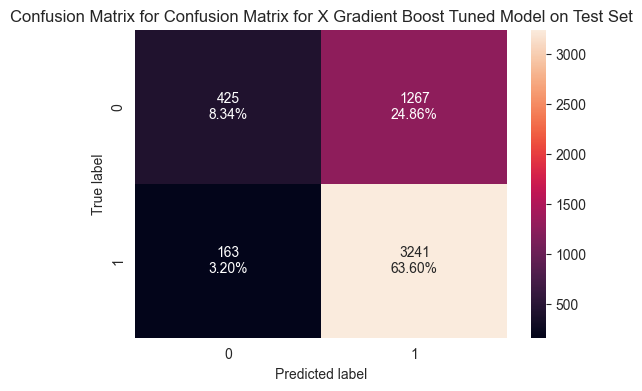

|  | Feature | Importance |
| --- | --- | --- |
| 9 | education_of_employee_High School | 0.390531 |
| 11 | has_job_experience_Y | 0.111147 |
| 19 | unit_of_wage_Year | 0.064366 |
| 10 | education_of_employee_Master's | 0.055774 |
| 4 | continent_Europe | 0.054530 |
| 8 | education_of_employee_Doctorate | 0.047874 |
| 13 | region_of_employment_Midwest | 0.040622 |
| 15 | region_of_employment_South | 0.037031 |
| 20 | full_time_position_Y | 0.023674 |
| 5 | continent_North America | 0.020110 |
| 2 | prevailing_wage | 0.019412 |
| 14 | region_of_employment_Northeast | 0.017962 |
| 16 | region_of_employment_West | 0.015460 |
| 3 | continent_Asia | 0.014183 |
| 17 | unit_of_wage_Month | 0.014049 |
| 12 | requires_job_training_Y | 0.013658 |
| 6 | continent_Oceania | 0.013531 |
| 7 | continent_South America | 0.013155 |
| 18 | unit_of_wage_Week | 0.011366 |
| 1 | yr_of_estab | 0.010870 |
| 0 | no_of_employees | 0.010697 |

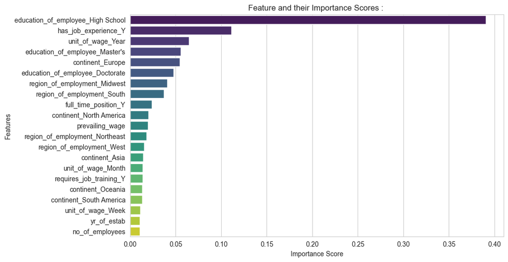

```
CPU times: user 4.8 s, sys: 2.51 s, total: 7.32 s
Wall time: 19.4 s
```

```python
%%time
# Choose the type of classifier.
xgb_tuned = XGBClassifier(random_state=EDA.RANDOM_STATE, eval_metric="logloss")

# Grid of parameters to choose from
parameters = {
    'n_estimators':np.arange(50,110,25),
    'scale_pos_weight':[1,2,5],
    'learning_rate':[0.01,0.1,0.05],
    'gamma':[1,3],
    'subsample':[0.7,0.9]
}

# Type of scoring used to compare parameter combinations
acc_scorer = metrics.make_scorer(metrics.f1_score)

# Run the grid search
grid_obj = GridSearchCV(estimator=xgb_tuned,param_grid=parameters,scoring=acc_scorer,cv=5,n_jobs=5)  ## Complete the code to define the grid search object
grid_obj = grid_obj.fit(X_train_over, y_train_over)

# Set the clf to the best combination of parameters
xgb_tuned = grid_obj.best_estimator_

# Fit the best algorithm to the data.
xgb_tuned.fit(X_train, y_train)


# Set the clf to the best combination of parameters
xgb_tuned = grid_obj.best_estimator_

# Fit the best algorithm to the data.
xgb_tuned.fit(X_train, y_train)

results = MLM.model_performance_classification(xgb_tuned, X_train, y_train)
results["Type"] = "OverTuned"
results["ModelName"] = "XGradientBoostTuned"
results["Run"] = "Training"
model_results = pd.concat([model_results, results], ignore_index=True)

results = MLM.model_performance_classification(xgb_tuned, X_val, y_val)
results["Type"] = "OverTuned"
results["ModelName"] = "XGradientBoostTuned"
results["Run"] = "Validation"
model_results = pd.concat([model_results, results], ignore_index=True)

results = MLM.model_performance_classification(xgb_tuned, X_test, y_test)
results["Type"] = "OverTuned"
results["ModelName"] = "XGradientBoostTuned"
results["Run"] = "Testing"
model_results = pd.concat([model_results, results], ignore_index=True)

models.append(("XGradientBoostTuned", xgb_tuned))

MLM.plot_confusion_matrix(model=xgb_tuned, predictors=X_train, expected=y_train,
                            title="Confusion Matrix for X Gradient Boost Tuned Model on Training Set")
MLM.plot_confusion_matrix(model=xgb_tuned, predictors=X_val, expected=y_val,
                            title="Confusion Matrix for X Gradient Boost Tuned Model on Validation Set")
MLM.plot_confusion_matrix(model=xgb_tuned, predictors=X_test, expected=y_test,
                            title="Confusion Matrix for X Gradient Boost Tuned Model on Test Set")

MLM.plot_feature_importance(model=xgb_tuned, features=X_train.columns)
```

|  | Type | ModelName | Run | Accuracy | Recall | Precision | F1 |
| --- | --- | --- | --- | --- | --- | --- | --- |
| 45 | OverTuned | RandomForestTuned | Training | 0.859956 | 0.945843 | 0.858794 | 0.900219 |
| 46 | OverTuned | RandomForestTuned | Validation | 0.742739 | 0.868645 | 0.773822 | 0.818496 |
| 47 | OverTuned | RandomForestTuned | Testing | 0.731162 | 0.860752 | 0.765813 | 0.810512 |
| 48 | OverTuned | AdaBoostTuned | Training | 0.751897 | 0.873959 | 0.780752 | 0.824731 |
| 49 | OverTuned | AdaBoostTuned | Validation | 0.744702 | 0.874816 | 0.772845 | 0.820675 |
| 50 | OverTuned | AdaBoostTuned | Testing | 0.741758 | 0.872503 | 0.771028 | 0.818633 |
| 51 | OverTuned | GradientBoostTuned | Training | 0.757457 | 0.877387 | 0.784845 | 0.828540 |
| 52 | OverTuned | GradientBoostTuned | Validation | 0.746860 | 0.877755 | 0.773634 | 0.822412 |
| 53 | OverTuned | GradientBoostTuned | Testing | 0.738030 | 0.870153 | 0.768353 | 0.816090 |
| 54 | OverTuned | XGradientBoostTuned | Training | 0.755298 | 0.974048 | 0.741022 | 0.841704 |
| 55 | OverTuned | XGradientBoostTuned | Validation | 0.724097 | 0.961505 | 0.719595 | 0.823145 |
| 56 | OverTuned | XGradientBoostTuned | Testing | 0.719388 | 0.952115 | 0.718944 | 0.819262 |

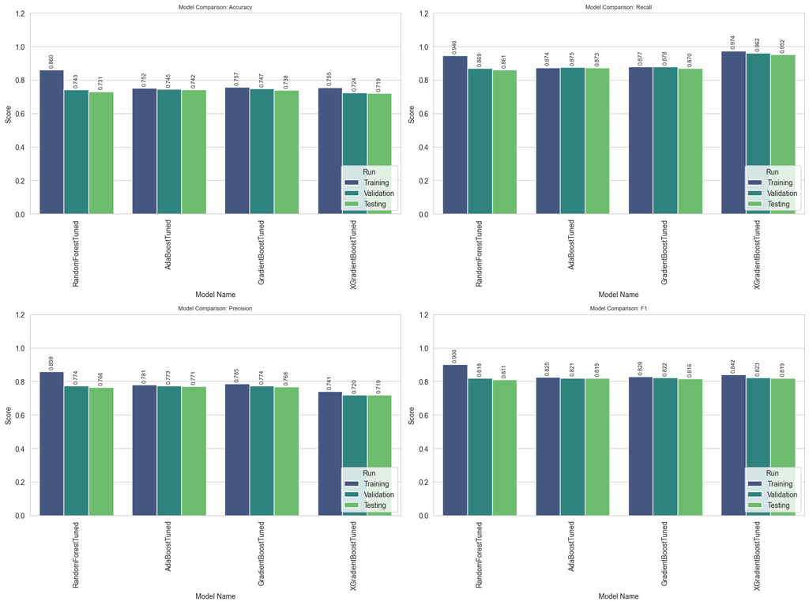

```python
display(model_results[model_results["Type"] == "OverTuned"])
showgraph(model_results[model_results["Type"] == "OverTuned"].sort_values(by="Type", ascending=False), title="Model Comparison Oversampled Tuned Data")
```

## Hyperparameter Tuning - Bagging Classifier

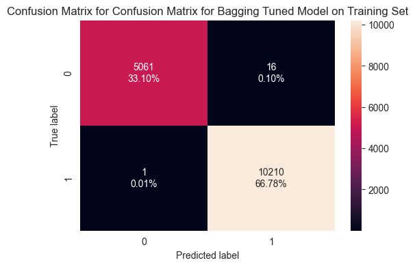

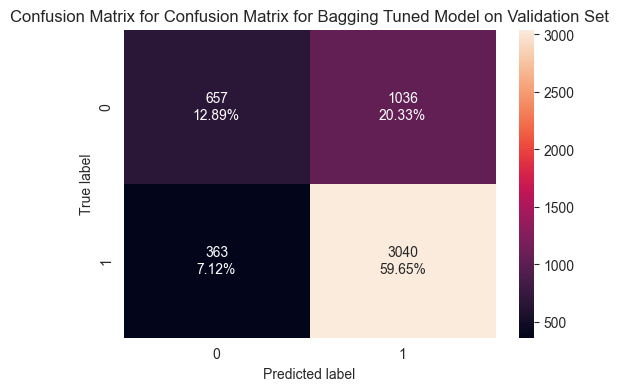

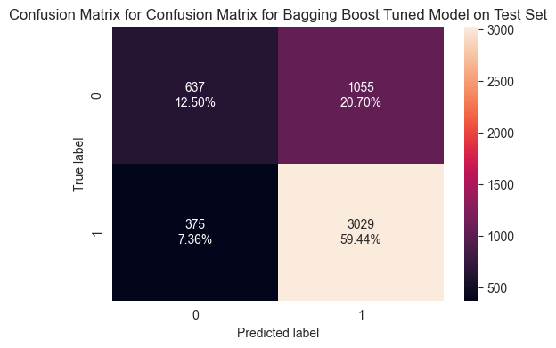

```
CPU times: user 8.51 s, sys: 359 ms, total: 8.87 s
Wall time: 45.2 s
```

```python
%%time
# Choose the type of classifier.
bagging_tuned = BaggingClassifier(random_state=EDA.RANDOM_STATE)

# Grid of parameters to choose from
parameters = {
    'max_samples': [0.8,0.9,1],
    'max_features': [0.7,0.8,0.9],
    'n_estimators' : [30,50,70],
}

# Type of scoring used to compare parameter combinations
acc_scorer = metrics.make_scorer(metrics.f1_score)

# Run the grid search
grid_obj = GridSearchCV(estimator=bagging_tuned,param_grid=parameters,scoring=acc_scorer,cv=5,n_jobs=5)  ## Complete the code to define the grid search object
grid_obj = grid_obj.fit(X_train_over, y_train_over)

# Set the clf to the best combination of parameters
bagging_tuned = grid_obj.best_estimator_

# Fit the best algorithm to the data.
bagging_tuned.fit(X_train, y_train)


# Set the clf to the best combination of parameters
bagging_tuned = grid_obj.best_estimator_

# Fit the best algorithm to the data.
bagging_tuned.fit(X_train, y_train)

results = MLM.model_performance_classification(bagging_tuned, X_train, y_train)
results["Type"] = "OverTuned"
results["ModelName"] = "BaggingTuned"
results["Run"] = "Training"
model_results = pd.concat([model_results, results], ignore_index=True)

results = MLM.model_performance_classification(bagging_tuned, X_val, y_val)
results["Type"] = "OverTuned"
results["ModelName"] = "BaggingTuned"
results["Run"] = "Validation"
model_results = pd.concat([model_results, results], ignore_index=True)

results = MLM.model_performance_classification(bagging_tuned, X_test, y_test)
results["Type"] = "OverTuned"
results["ModelName"] = "BaggingTuned"
results["Run"] = "Testing"
model_results = pd.concat([model_results, results], ignore_index=True)

models.append(("BaggingTuned", bagging_tuned))

MLM.plot_confusion_matrix(model=bagging_tuned, predictors=X_train, expected=y_train,
                            title="Confusion Matrix for Bagging Tuned Model on Training Set")
MLM.plot_confusion_matrix(model=bagging_tuned, predictors=X_val, expected=y_val,
                            title="Confusion Matrix for Bagging Tuned Model on Validation Set")
MLM.plot_confusion_matrix(model=bagging_tuned, predictors=X_test, expected=y_test,
                            title="Confusion Matrix for Bagging Boost Tuned Model on Test Set")
```

|  | Type | ModelName | Run | Accuracy | Recall | Precision | F1 |
| --- | --- | --- | --- | --- | --- | --- | --- |
| 45 | OverTuned | RandomForestTuned | Training | 0.859956 | 0.945843 | 0.858794 | 0.900219 |
| 46 | OverTuned | RandomForestTuned | Validation | 0.742739 | 0.868645 | 0.773822 | 0.818496 |
| 47 | OverTuned | RandomForestTuned | Testing | 0.731162 | 0.860752 | 0.765813 | 0.810512 |
| 48 | OverTuned | AdaBoostTuned | Training | 0.751897 | 0.873959 | 0.780752 | 0.824731 |
| 49 | OverTuned | AdaBoostTuned | Validation | 0.744702 | 0.874816 | 0.772845 | 0.820675 |
| 50 | OverTuned | AdaBoostTuned | Testing | 0.741758 | 0.872503 | 0.771028 | 0.818633 |
| 51 | OverTuned | GradientBoostTuned | Training | 0.757457 | 0.877387 | 0.784845 | 0.828540 |
| 52 | OverTuned | GradientBoostTuned | Validation | 0.746860 | 0.877755 | 0.773634 | 0.822412 |
| 53 | OverTuned | GradientBoostTuned | Testing | 0.738030 | 0.870153 | 0.768353 | 0.816090 |
| 54 | OverTuned | XGradientBoostTuned | Training | 0.755298 | 0.974048 | 0.741022 | 0.841704 |
| 55 | OverTuned | XGradientBoostTuned | Validation | 0.724097 | 0.961505 | 0.719595 | 0.823145 |
| 56 | OverTuned | XGradientBoostTuned | Testing | 0.719388 | 0.952115 | 0.718944 | 0.819262 |
| 57 | OverTuned | BaggingTuned | Training | 0.998888 | 0.999902 | 0.998435 | 0.999168 |
| 58 | OverTuned | BaggingTuned | Validation | 0.725471 | 0.893329 | 0.745829 | 0.812943 |
| 59 | OverTuned | BaggingTuned | Testing | 0.719388 | 0.889835 | 0.741675 | 0.809028 |

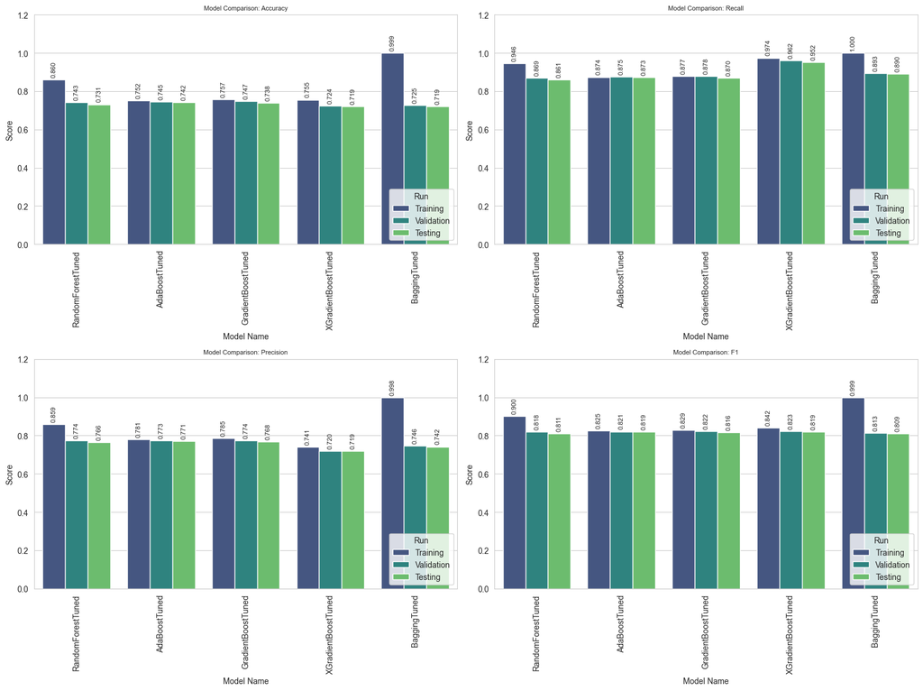

```python
display(model_results[model_results["Type"] == "OverTuned"])
showgraph(model_results[model_results["Type"] == "OverTuned"].sort_values(by="Type", ascending=False), title="Model Comparison Oversampled Tuend Data")
```

## Hyperparameter Tuning - Decision Tree

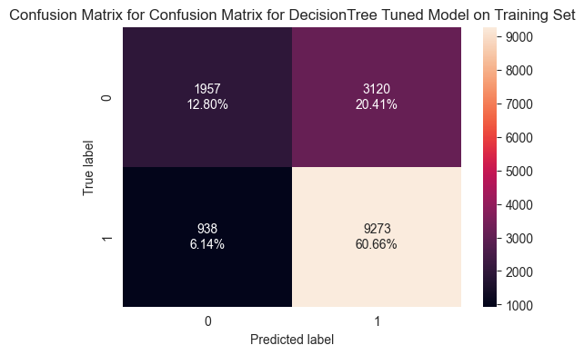

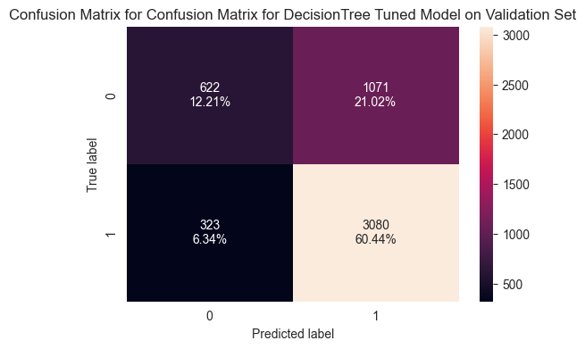

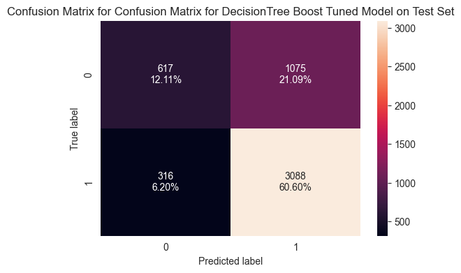

|  | Feature | Importance |
| --- | --- | --- |
| 9 | education_of_employee_High School | 0.395495 |
| 11 | has_job_experience_Y | 0.231474 |
| 19 | unit_of_wage_Year | 0.152641 |
| 4 | continent_Europe | 0.067527 |
| 10 | education_of_employee_Master's | 0.058238 |
| 13 | region_of_employment_Midwest | 0.047772 |
| 8 | education_of_employee_Doctorate | 0.032245 |
| 5 | continent_North America | 0.014609 |
| 18 | unit_of_wage_Week | 0.000000 |
| 17 | unit_of_wage_Month | 0.000000 |
| 16 | region_of_employment_West | 0.000000 |
| 15 | region_of_employment_South | 0.000000 |
| 14 | region_of_employment_Northeast | 0.000000 |
| 0 | no_of_employees | 0.000000 |
| 12 | requires_job_training_Y | 0.000000 |
| 1 | yr_of_estab | 0.000000 |
| 7 | continent_South America | 0.000000 |
| 6 | continent_Oceania | 0.000000 |
| 3 | continent_Asia | 0.000000 |
| 2 | prevailing_wage | 0.000000 |
| 20 | full_time_position_Y | 0.000000 |

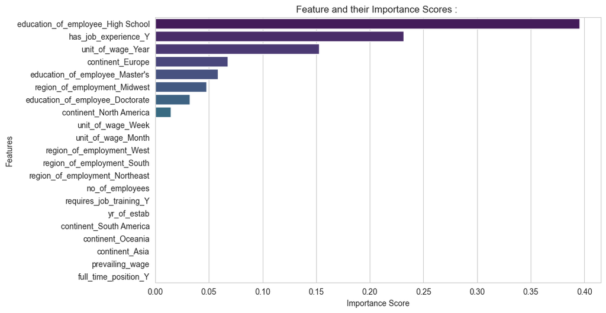

```
CPU times: user 1.2 s, sys: 297 ms, total: 1.5 s
Wall time: 2.15 s
```

```python
%%time
# Choose the type of classifier.
decisiontree_tuned = DecisionTreeClassifier(random_state=EDA.RANDOM_STATE)

# Grid of parameters to choose from
parameters = {
    'max_depth': np.arange(2,6),
    'min_samples_leaf': [1, 4, 7],
    'max_leaf_nodes' : [10, 15],
    'min_impurity_decrease': [0.0001,0.001]
}

# Type of scoring used to compare parameter combinations
acc_scorer = metrics.make_scorer(metrics.f1_score)

# Run the grid search
grid_obj = GridSearchCV(estimator=decisiontree_tuned,param_grid=parameters,scoring=acc_scorer,cv=5,n_jobs=5)  ## Complete the code to define the grid search object
grid_obj = grid_obj.fit(X_train_over, y_train_over)

# Set the clf to the best combination of parameters
decisiontree_tuned = grid_obj.best_estimator_

# Fit the best algorithm to the data.
decisiontree_tuned.fit(X_train, y_train)


# Set the clf to the best combination of parameters
decisiontree_tuned = grid_obj.best_estimator_

# Fit the best algorithm to the data.
decisiontree_tuned.fit(X_train, y_train)

results = MLM.model_performance_classification(decisiontree_tuned, X_train, y_train)
results["Type"] = "OverTuned"
results["ModelName"] = "DecisionTreeTuned"
results["Run"] = "Training"
model_results = pd.concat([model_results, results], ignore_index=True)

results = MLM.model_performance_classification(decisiontree_tuned, X_val, y_val)
results["Type"] = "OverTuned"
results["ModelName"] = "DecisionTreeTuned"
results["Run"] = "Validation"
model_results = pd.concat([model_results, results], ignore_index=True)

results = MLM.model_performance_classification(decisiontree_tuned, X_test, y_test)
results["Type"] = "OverTuned"
results["ModelName"] = "DecisionTreeTuned"
results["Run"] = "Testing"
model_results = pd.concat([model_results, results], ignore_index=True)

models.append(("DecisionTreeTuned", decisiontree_tuned))


MLM.plot_confusion_matrix(model=decisiontree_tuned, predictors=X_train, expected=y_train,
                            title="Confusion Matrix for DecisionTree Tuned Model on Training Set")
MLM.plot_confusion_matrix(model=decisiontree_tuned, predictors=X_val, expected=y_val,
                            title="Confusion Matrix for DecisionTree Tuned Model on Validation Set")
MLM.plot_confusion_matrix(model=decisiontree_tuned, predictors=X_test, expected=y_test,
                            title="Confusion Matrix for DecisionTree Boost Tuned Model on Test Set")

MLM.plot_feature_importance(model=decisiontree_tuned, features=X_train.columns)
```

|  | Type | ModelName | Run | Accuracy | Recall | Precision | F1 |
| --- | --- | --- | --- | --- | --- | --- | --- |
| 45 | OverTuned | RandomForestTuned | Training | 0.859956 | 0.945843 | 0.858794 | 0.900219 |
| 46 | OverTuned | RandomForestTuned | Validation | 0.742739 | 0.868645 | 0.773822 | 0.818496 |
| 47 | OverTuned | RandomForestTuned | Testing | 0.731162 | 0.860752 | 0.765813 | 0.810512 |
| 48 | OverTuned | AdaBoostTuned | Training | 0.751897 | 0.873959 | 0.780752 | 0.824731 |
| 49 | OverTuned | AdaBoostTuned | Validation | 0.744702 | 0.874816 | 0.772845 | 0.820675 |
| 50 | OverTuned | AdaBoostTuned | Testing | 0.741758 | 0.872503 | 0.771028 | 0.818633 |
| 51 | OverTuned | GradientBoostTuned | Training | 0.757457 | 0.877387 | 0.784845 | 0.828540 |
| 52 | OverTuned | GradientBoostTuned | Validation | 0.746860 | 0.877755 | 0.773634 | 0.822412 |
| 53 | OverTuned | GradientBoostTuned | Testing | 0.738030 | 0.870153 | 0.768353 | 0.816090 |
| 54 | OverTuned | XGradientBoostTuned | Training | 0.755298 | 0.974048 | 0.741022 | 0.841704 |
| 55 | OverTuned | XGradientBoostTuned | Validation | 0.724097 | 0.961505 | 0.719595 | 0.823145 |
| 56 | OverTuned | XGradientBoostTuned | Testing | 0.719388 | 0.952115 | 0.718944 | 0.819262 |
| 57 | OverTuned | BaggingTuned | Training | 0.998888 | 0.999902 | 0.998435 | 0.999168 |
| 58 | OverTuned | BaggingTuned | Validation | 0.725471 | 0.893329 | 0.745829 | 0.812943 |
| 59 | OverTuned | BaggingTuned | Testing | 0.719388 | 0.889835 | 0.741675 | 0.809028 |
| 60 | OverTuned | DecisionTreeTuned | Training | 0.734563 | 0.908138 | 0.748245 | 0.820474 |
| 61 | OverTuned | DecisionTreeTuned | Validation | 0.726452 | 0.905084 | 0.741990 | 0.815462 |
| 62 | OverTuned | DecisionTreeTuned | Testing | 0.727041 | 0.907168 | 0.741773 | 0.816175 |

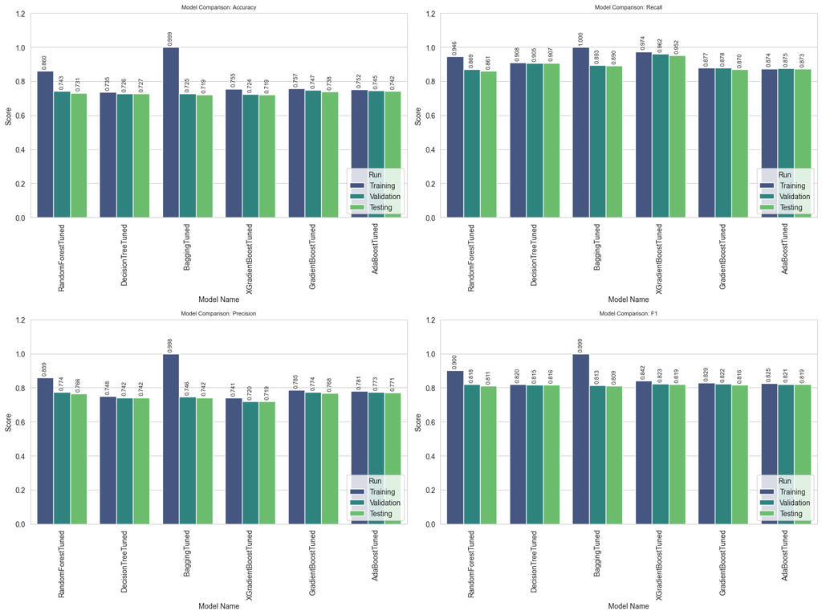

```python
display(model_results[model_results["Type"] == "OverTuned"])
showgraph(model_results[model_results["Type"] == "OverTuned"].sort_values(by="Type", ascending=False), title="Model Comparison Oversampled Tuned Data")
```

# **Model Comparison and Final Model Selection**

|  | Type | ModelName | Run | Accuracy | Recall | Precision | F1 |
| --- | --- | --- | --- | --- | --- | --- | --- |
| 57 | OverTuned | BaggingTuned | Training | 0.998888 | 0.999902 | 0.998435 | 0.999168 |
| 45 | OverTuned | RandomForestTuned | Training | 0.859956 | 0.945843 | 0.858794 | 0.900219 |
| 54 | OverTuned | XGradientBoostTuned | Training | 0.755298 | 0.974048 | 0.741022 | 0.841704 |
| 51 | OverTuned | GradientBoostTuned | Training | 0.757457 | 0.877387 | 0.784845 | 0.828540 |
| 48 | OverTuned | AdaBoostTuned | Training | 0.751897 | 0.873959 | 0.780752 | 0.824731 |
| 55 | OverTuned | XGradientBoostTuned | Validation | 0.724097 | 0.961505 | 0.719595 | 0.823145 |
| 52 | OverTuned | GradientBoostTuned | Validation | 0.746860 | 0.877755 | 0.773634 | 0.822412 |
| 49 | OverTuned | AdaBoostTuned | Validation | 0.744702 | 0.874816 | 0.772845 | 0.820675 |
| 60 | OverTuned | DecisionTreeTuned | Training | 0.734563 | 0.908138 | 0.748245 | 0.820474 |
| 56 | OverTuned | XGradientBoostTuned | Testing | 0.719388 | 0.952115 | 0.718944 | 0.819262 |
| 50 | OverTuned | AdaBoostTuned | Testing | 0.741758 | 0.872503 | 0.771028 | 0.818633 |
| 46 | OverTuned | RandomForestTuned | Validation | 0.742739 | 0.868645 | 0.773822 | 0.818496 |
| 62 | OverTuned | DecisionTreeTuned | Testing | 0.727041 | 0.907168 | 0.741773 | 0.816175 |
| 53 | OverTuned | GradientBoostTuned | Testing | 0.738030 | 0.870153 | 0.768353 | 0.816090 |
| 61 | OverTuned | DecisionTreeTuned | Validation | 0.726452 | 0.905084 | 0.741990 | 0.815462 |
| 58 | OverTuned | BaggingTuned | Validation | 0.725471 | 0.893329 | 0.745829 | 0.812943 |
| 47 | OverTuned | RandomForestTuned | Testing | 0.731162 | 0.860752 | 0.765813 | 0.810512 |
| 59 | OverTuned | BaggingTuned | Testing | 0.719388 | 0.889835 | 0.741675 | 0.809028 |

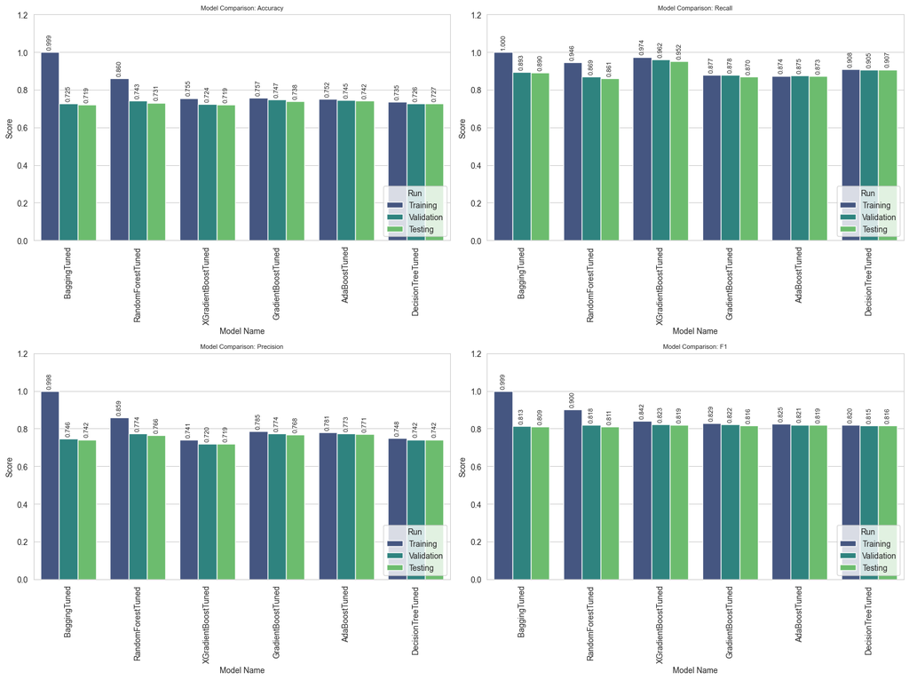

```python
# Type	ModelName	Run	Accuracy	Recall	Precision	F1
#df_T = model_results[(model_results["Type"] == "OverTuned") & ((model_results["Run"] == "Testing")| (model_results["Run"] == "Validation"))].sort_values(by="F1", ascending=False)
df_T = model_results[(model_results["Type"] == "OverTuned")].sort_values(by="F1", ascending=False)
display(df_T)

showgraph(df_T, title="Model Comparison Oversampled Tuned Data")
# model_results
```

# **Actionable Insights and Recommendations**

#### Model Performance Comparative Analysis

The following analysis evaluates how each tuned model generalized across different datasets.

| Model Name | Run Type | Accuracy | Recall | Precision | F1-Score |
| --- | --- | --- | --- | --- | --- |
| **XGradientBoost (Tuned)** | Training | 0.755298 | 0.974048 | 0.741022 | 0.841704 |
|  | Validation | 0.724097 | 0.961505 | 0.719595 | 0.823145 |
|  | **Testing** | **0.719388** | **0.952115** | **0.718944** | **0.819262** |
| **AdaBoost (Tuned)** | Training | 0.751897 | 0.873959 | 0.780752 | 0.824731 |
|  | Validation | 0.744702 | 0.874816 | 0.772845 | 0.820675 |
|  | **Testing** | **0.741758** | **0.872503** | **0.771028** | **0.818633** |
| **DecisionTree (Tuned)** | Training | 0.734563 | 0.908138 | 0.748245 | 0.820474 |
|  | Validation | 0.726452 | 0.905084 | 0.741990 | 0.815462 |
|  | **Testing** | **0.727041** | **0.907168** | **0.741773** | **0.816175** |
| **GradientBoost (Tuned)** | Training | 0.757457 | 0.877387 | 0.784845 | 0.828540 |
|  | Validation | 0.746860 | 0.877755 | 0.773634 | 0.822412 |
|  | **Testing** | **0.738030** | **0.870153** | **0.768353** | **0.816090** |
| **RandomForest (Tuned)** | Training | 0.859956 | 0.945843 | 0.858794 | 0.900219 |
|  | Validation | 0.742739 | 0.868645 | 0.773822 | 0.818496 |
|  | **Testing** | **0.731162** | **0.860752** | **0.765813** | **0.810512** |
| **Bagging (Tuned)** | Training | 0.998888 | 0.999902 | 0.998435 | 0.999168 |
|  | Validation | 0.725471 | 0.893329 | 0.745829 | 0.812943 |
|  | **Testing** | **0.719388** | **0.889835** | **0.741675** | **0.809028** |

#### 1. Overfitting and Generalization

- **Extreme Overfitting:** **Bagging (Tuned)** and **RandomForest (Tuned)** exhibit significant overfitting. Bagging achieves a near-perfect Training F1 of 0.999 - drops to 0.809 on Testing. RandomForest drops from a 0.900 Training F1 to 0.810 on Testing.
- **Best Generalization:** **XGradientBoost**, **AdaBoost**, and **GradientBoost** show excellent stability, with very narrow gaps between training and testing metrics, indicating robust performance on unseen data.

#### 2. Trade-offs

- **High Sensitivity (Recall):** **XGradientBoost (Tuned)** is the strongest model for identifying the majority class, maintaining a testing Recall of **0.952**.
- **High Precision:** **AdaBoost (Tuned)** and **GradientBoost (Tuned)** offer the highest precision on testing (0.771 and 0.768, respectively), making them suitable if the cost of "False Positives" is high.

#### 3. Best Model : XGradientBoost (Tuned)

The **XGradientBoost (Tuned)** model is the recommended choice for deployment.

- **Top Performance:** It achieved the highest overall **Testing F1-score (0.819)**.
- **Exceptional Recall:** Its ability to correctly identify 95.2% of positive cases makes it highly effective for real-world scenarios where missing a case is expensive.
- **Robustness:** The model shows minimal decay from validation to testing, proving its reliability.

#### 4. Strategic Recommendations

- **Prioritize Boosting:** The boosting models (XGB, AdaBoost, GradientBoost) outperforms the bagging models in generalization.
- **Address Precision Needs:** If the case requires fewer false alarms, we should use **AdaBoost (Tuned)**, it maintains the highest Accuracy (0.741) and Precision (0.771) with a reasonable F1-score.
- **Regularize Bagging Models:** To use Bagging or RandomForest effectively, further pruning or stricter constraints on tree depth are needed to curb the drastic drop between training and testing.

```python
!jupyter nbconvert --to html "Project_Full_Code_Notebook_EasyVisa.ipynb"
```